# Propensity Scores and the Right Heart Catheterization Data

# 4 The 50 Covariates We’ll Study

Our propensity model will eventually include 50 covariates, described below.

## 4.1 Group 1: Socio-demographics (6 covariates)

| Variable | Definition |
| --- | --- |
| `age` | Age in years |
| `sex` | Sex |
| `edu` | Years of Education |
| `income` | Income Category (4 levels) |
| `ninsclas` | Insurance Category (6 levels) |
| `race` | Self-Reported Race (3 levels) |

Here’s a Table 1 for these covariates.

```r
vars01 <- c("age", "sex", "edu", "income", "ninsclas", "race")

table1_01 <-
    CreateTableOne(vars = vars01, strata = "swang1",
                   data = rhc_cleaning, test = FALSE)

print(table1_01, smd = TRUE)
```

```
                        Stratified by swang1
                         RHC           No RHC        SMD
  n                       2184          3551
  age (mean (SD))        60.75 (15.63) 61.76 (17.29)  0.061
  sex = Female (%)         906 (41.5)   1637 (46.1)   0.093
  edu (mean (SD))        11.86 (3.16)  11.57 (3.13)   0.091
  income (%)                                          0.142
     Under $11k           1145 (52.4)   2081 (58.6)
     $11-$25k              452 (20.7)    713 (20.1)
     $25-$50k              393 (18.0)    500 (14.1)
     > $50k                194 ( 8.9)    257 ( 7.2)
  ninsclas (%)                                        0.194
     Private               731 (33.5)    967 (27.2)
     Private & Medicare    490 (22.4)    746 (21.0)
     Medicare              511 (23.4)    947 (26.7)
     Medicare & Medicaid   123 ( 5.6)    251 ( 7.1)
     Medicaid              193 ( 8.8)    454 (12.8)
     No insurance          136 ( 6.2)    186 ( 5.2)
  race (%)                                            0.036
     white                1707 (78.2)   2753 (77.5)
     black                 335 (15.3)    585 (16.5)
     other                 142 ( 6.5)    213 ( 6.0)
```

- Two of these covariates show standardized mean differences larger than 0.10.

## 4.2 Group 2: Presentation at Admission (7 covariates)

| Variable | Definition |
| --- | --- |
| `cat1` | Primary disease category (9 levels) |
| `dnr1` | Do Not Resuscitate status, day 1 |
| `wtkilo1` | Weight in kg, day 1 |
| `hrt1` | Heart rate, day 1 |
| `meanbp1` | Mean Blood Pressure, day 1 |
| `resp1` | Respiratory rate, day 1 |
| `temp1` | Temperature, C, day 1 |

```r
vars02 <- c("cat1", "dnr1", "wtkilo1", "hrt1", "meanbp1",
          "resp1", "temp1")

table1_02 <-
    CreateTableOne(vars = vars02, strata = "swang1",
                   data = rhc_cleaning, test = FALSE)

print(table1_02, smd = TRUE)
```

```
                      Stratified by swang1
                       RHC            No RHC         SMD
  n                      2184           3551
  cat1 (%)                                            0.583
     ARF                  909 (41.6)    1581 (44.5)
     CHF                  209 ( 9.6)     247 ( 7.0)
     Cirrhosis             49 ( 2.2)     175 ( 4.9)
     Colon Cancer           1 ( 0.0)       6 ( 0.2)
     Coma                  95 ( 4.3)     341 ( 9.6)
     COPD                  58 ( 2.7)     399 (11.2)
     Lung Cancer            5 ( 0.2)      34 ( 1.0)
     MOSF w/Malignancy    158 ( 7.2)     241 ( 6.8)
     MOSF w/Sepsis        700 (32.1)     527 (14.8)
  dnr1 = Yes (%)          155 ( 7.1)     499 (14.1)   0.228
  wtkilo1 (mean (SD))   72.36 (27.73)  65.04 (29.50)  0.256
  hrt1 (mean (SD))     118.93 (41.47) 112.87 (40.94)  0.147
  meanbp1 (mean (SD))   68.20 (34.24)  84.87 (38.87)  0.455
  resp1 (mean (SD))     26.65 (14.17)  28.98 (13.95)  0.165
  temp1 (mean (SD))     37.59 (1.83)   37.63 (1.74)   0.021
```

- Six of these covariates show standardized mean differences larger than 0.10.

## 4.3 Group 3: Admission Diagnosis Categories (10 covariates)

| Variable | Definition |
| --- | --- |
| `card` | Cardiovascular diagnosis |
| `gastr` | Gastrointestinal diagnosis |
| `hema` | Hematologic diagnosis |
| `meta` | Metabolic diagnosis |
| `neuro` | Neurological diagnosis |
| `ortho` | Orthopedic diagnosis |
| `renal` | Renal diagnosis |
| `resp` | Respiratory diagnosis |
| `seps` | Sepsis diagnosis |
| `trauma` | Trauma diagnosis |

```r
vars03 <- c("card", "gastr", "hema", "meta", "neuro", "ortho",
          "renal", "resp", "seps", "trauma")

table1_03 <-
    CreateTableOne(vars = vars03, strata = "swang1",
                   data = rhc_cleaning, test = FALSE)

print(table1_03, smd = TRUE)
```

```
                  Stratified by swang1
                   RHC          No RHC       SMD
  n                2184         3551
  card = Yes (%)    924 (42.3)  1007 (28.4)   0.295
  gastr = Yes (%)   420 (19.2)   522 (14.7)   0.121
  hema = Yes (%)    115 ( 5.3)   239 ( 6.7)   0.062
  meta = Yes (%)     93 ( 4.3)   172 ( 4.8)   0.028
  neuro = Yes (%)   118 ( 5.4)   575 (16.2)   0.353
  ortho = Yes (%)     4 ( 0.2)     3 ( 0.1)   0.027
  renal = Yes (%)   148 ( 6.8)   147 ( 4.1)   0.116
  resp = Yes (%)    632 (28.9)  1481 (41.7)   0.270
  seps = Yes (%)    516 (23.6)   515 (14.5)   0.234
  trauma = Yes (%)   34 ( 1.6)    18 ( 0.5)   0.104
```

- Seven of these covariates show standardized mean differences larger than 0.10.

## 4.4 Group 4: Comorbid Illness and Transfer Status (13 covariates)

| Variable | Definition |
| --- | --- |
| `amihx` | Definite Myocardial Infarction |
| `ca` | Cancer (3 levels) |
| `cardiohx` | Acute MI, Peripheral Vascular Disease, Severe Cardiovascular Symptoms (NYHA-Class III), Very Severe Cardiovascular Symptoms (NYHA- IV) |
| `chfhx` | Congestive Heart Failure |
| `chrpulhx` | Chronic Pulmonary Disease, Severe or Very Severe Pulmonary Disease |
| `dementhx` | Dementia, Stroke or Cerebral Infarct, Parkinson’s Disease |
| `gibledhx` | Upper GI Bleeding |
| `immunhx` | Immunosupperssion, Organ Transplant, HIV Positivity, Diabetes Mellitus Without End Organ Damage, Diabetes Mellitus With End Organ Damage, Connective Tissue Disease |
| `liverhx` | Cirrhosis, Hepatic Failure |
| `malighx` | Solid Tumor, Metastatic Disease, Chronic Leukemia/Myeloma, Acute Leukemia, Lymphoma |
| `psychhx` | Psychiatric History, Active Psychosis or Severe Depression |
| `renalhx` | Chronic Renal Disease, Chronic Hemodialysis or Peritoneal Dialysis |
| `transhx` | Transfer (> 24 Hours) from Another Hospital |

```r
vars04 <- c("amihx", "ca", "cardiohx", "chfhx", "chrpulhx", "dementhx",
          "gibledhx", "immunhx", "liverhx", "malighx", "psychhx", "renalhx", "transhx")

table1_04 <-
    CreateTableOne(vars = vars04, strata = "swang1",
                   data = rhc_cleaning, test = FALSE)

print(table1_04, smd = TRUE)
```

```
                      Stratified by swang1
                       RHC          No RHC       SMD
  n                    2184         3551
  amihx (mean (SD))    0.04 (0.20)  0.03 (0.17)   0.074
  ca (%)                                          0.107
     No                1727 (79.1)  2652 (74.7)
     Yes                334 (15.3)   638 (18.0)
     Metastatic         123 ( 5.6)   261 ( 7.4)
  cardiohx (mean (SD)) 0.20 (0.40)  0.16 (0.37)   0.116
  chfhx (mean (SD))    0.19 (0.40)  0.17 (0.37)   0.069
  chrpulhx (mean (SD)) 0.14 (0.35)  0.22 (0.41)   0.192
  dementhx (mean (SD)) 0.07 (0.25)  0.12 (0.32)   0.163
  gibledhx (mean (SD)) 0.02 (0.16)  0.04 (0.19)   0.070
  immunhx (mean (SD))  0.29 (0.45)  0.26 (0.44)   0.080
  liverhx (mean (SD))  0.06 (0.24)  0.07 (0.26)   0.049
  malighx (mean (SD))  0.20 (0.40)  0.25 (0.43)   0.101
  psychhx (mean (SD))  0.05 (0.21)  0.08 (0.27)   0.143
  renalhx (mean (SD))  0.05 (0.21)  0.04 (0.20)   0.032
  transhx (mean (SD))  0.15 (0.36)  0.09 (0.29)   0.170
```

- Seven of these covariates show standardized mean differences larger than 0.10.

## 4.5 Group 5: Day 1 Summary Measures of Presentation / Severity of Illness (4 covariates)

| Variable | Definition |
| --- | --- |
| `aps1` | APACHE III score ignoring Coma, day 1 |
| `das2d3pc` | DASI (Duke Activity Status Index prior to admission) |
| `scoma1` | Support Coma score based on Glasgow, day 1 |
| `surv2md1` | SUPPORT model estimate of Prob(surviving 2 months) |

```r
vars05 <- c("aps1", "das2d3pc", "scoma1", "surv2md1")

table1_05 <-
    CreateTableOne(vars = vars05, strata = "swang1",
                   data = rhc_cleaning, test = FALSE)

print(table1_05, smd = TRUE)
```

```
                      Stratified by swang1
                       RHC           No RHC        SMD
  n                     2184          3551
  aps1 (mean (SD))     60.74 (20.27) 50.93 (18.81)  0.501
  das2d3pc (mean (SD)) 20.70 (5.03)  20.37 (5.48)   0.063
  scoma1 (mean (SD))   18.97 (28.26) 22.25 (31.37)  0.110
  surv2md1 (mean (SD))  0.57 (0.20)   0.61 (0.19)   0.198
```

- Three of these covariates show standardized mean differences larger than 0.10.

## 4.6 Group 6: Day 1 Lab Results (10 covariates)

| Variable | Definition |
| --- | --- |
| `alb1` | Albumin |
| `bili1` | Bilirubin |
| `crea1` | Serum Creatinine |
| `hema1` | Hematocrit |
| `paco21` | PaCo2 |
| `pafi1` | PaO2/(.01 FIO2) |
| `ph1` | Serum PH (arterial) |
| `pot1` | Serum Potassium |
| `sod1` | Serum Sodium |
| `wblc1` | White blood cell count (4 subjects with value 0) |

```r
vars06 <- c("alb1", "bili1", "crea1", "hema1", "paco21",
            "pafi1", "pot1", "sod1", "wblc1")

table1_06 <-
    CreateTableOne(vars = vars06, strata = "swang1",
                   data = rhc_cleaning, test = FALSE)

print(table1_06, smd = TRUE)
```

```
                    Stratified by swang1
                     RHC             No RHC          SMD
  n                    2184            3551
  alb1 (mean (SD))     2.98 (0.93)     3.16 (0.67)    0.230
  bili1 (mean (SD))    2.71 (5.33)     2.00 (4.43)    0.145
  crea1 (mean (SD))    2.47 (2.05)     1.92 (2.03)    0.270
  hema1 (mean (SD))   30.51 (7.42)    32.70 (8.79)    0.269
  paco21 (mean (SD))  36.79 (10.97)   39.95 (14.24)   0.249
  pafi1 (mean (SD))  192.43 (105.54) 240.63 (116.66)  0.433
  pot1 (mean (SD))     4.05 (1.01)     4.08 (1.04)    0.027
  sod1 (mean (SD))   136.33 (7.60)   137.04 (7.68)    0.092
  wblc1 (mean (SD))   16.27 (12.55)   15.26 (11.41)   0.084
```

- Six of these covariates show standardized mean differences larger than 0.10.

So, in all, 31 of the 50 covariates show standardized mean differences that exceed 0.10 before any propensity score adjustment.

# 5 A Little Refactoring

For our outcome, and our treatment, it will be useful to have 1/0 versions of the variables, and it will also be helpful to have the factor versions releveled to put the outcome of interest (death) first and the treatment of interest (RHC) first.

```r
rhc <- rhc_cleaning %>%
    mutate(treat_rhc = as.numeric(swang1 == "RHC"),
           swang1 = fct_relevel(swang1, "RHC"),
           death = fct_relevel(death, "Yes"),
           died = as.numeric(death == "Yes"))
```

## 5.1 Saving the Data File

```r
saveRDS(rhc, here("data", "rhc.Rds"))
```

# 6 Setting a Seed

I’m going to set a seed for random numbers before we start, which I can change later if I like.

```r
set.seed(50012345)
```

# 7 Unadjusted Outcome Assessments

Before we estimate a propensity score, we’ll perform unadjusted assessments to describe the impact of RHC (or not) on our three outcomes, without adjustment for any covariates at all.

## 7.1 Outcome A: In-Study Mortality (binary)

```r
rhc %>% tabyl(swang1, death) %>%
    adorn_totals() %>%
    adorn_percentages() %>%
    adorn_pct_formatting() %>%
    adorn_ns(position = "front") %>%
    adorn_title
```

```
               death
 swang1          Yes           No
    RHC 1486 (68.0%)  698 (32.0%)
 No RHC 2236 (63.0%) 1315 (37.0%)
  Total 3722 (64.9%) 2013 (35.1%)
```

The odds ratio of death associated with RHC as opposed to No RHC should be larger than 1, specifically, it should be

$$\frac{1486 \times 1315}{2236 \times 698} = 1.25$$

Let’s see if that’s what we get.

### 7.1.1 Fitting the Model with the 1/0 treatment and outcome

```r
death_unadj <- glm(died ~ treat_rhc, data = rhc, family = binomial())

death_unadj
```

```
Call:  glm(formula = died ~ treat_rhc, family = binomial(), data = rhc)

Coefficients:
(Intercept)    treat_rhc
     0.5309       0.2248

Degrees of Freedom: 5734 Total (i.e. Null);  5733 Residual
Null Deviance:      7433
Residual Deviance: 7418     AIC: 7422
```

```r
tidy(death_unadj, conf.int = TRUE, exponentiate = TRUE)
```

```
# A tibble: 2 x 7
  term        estimate std.error statistic  p.value conf.low conf.high
  <chr>          <dbl>     <dbl>     <dbl>    <dbl>    <dbl>     <dbl>
1 (Intercept)     1.70    0.0348     15.3  1.11e-52     1.59      1.82
2 treat_rhc       1.25    0.0576      3.90 9.43e- 5     1.12      1.40
```

### 7.1.2 Fitting the Model with the treatment and outcome as factors requires care

Alternatively, we could just work with the factors, but then, it’s important to be sure what is actually being modeled. Do this by making the outcome and treatment logical results, as follows.

```r
modelA_unadj1 <- glm((death == "Yes") ~ (swang1 == "RHC"), data = rhc, family = binomial())

tidy(modelA_unadj1, conf.int = TRUE, exponentiate = TRUE)
```

```
# A tibble: 2 x 7
  term                  estimate std.error statistic  p.value conf.low conf.high
  <chr>                    <dbl>     <dbl>     <dbl>    <dbl>    <dbl>     <dbl>
1 "(Intercept)"             1.70    0.0348     15.3  1.11e-52     1.59      1.82
2 "swang1 == \"RHC\"TR~     1.25    0.0576      3.90 9.43e- 5     1.12      1.40
```

Failing to do this can cause trouble:

```r
modelA_unadj_bad <- glm(death ~ swang1, data = rhc, family = binomial())

tidy(modelA_unadj_bad, conf.int = TRUE, exponentiate = TRUE)
```

```
# A tibble: 2 x 7
  term         estimate std.error statistic  p.value conf.low conf.high
  <chr>           <dbl>     <dbl>     <dbl>    <dbl>    <dbl>     <dbl>
1 (Intercept)     0.470    0.0459    -16.5  6.32e-61    0.429     0.514
2 swang1No RHC    1.25     0.0576      3.90 9.43e- 5    1.12      1.40
```

Note that this last version is actually predicting “Death = No” on the basis of “swang1 = No RHC”, which can be extremely confusing.

And if you did this:

```r
modelA_unadj_bad2 <- glm(death ~ swang1 == "RHC", data = rhc, family = binomial())

tidy(modelA_unadj_bad2, conf.int = TRUE, exponentiate = TRUE)
```

```
# A tibble: 2 x 7
  term                  estimate std.error statistic  p.value conf.low conf.high
  <chr>                    <dbl>     <dbl>     <dbl>    <dbl>    <dbl>     <dbl>
1 "(Intercept)"            0.588    0.0348    -15.3  1.11e-52    0.549     0.629
2 "swang1 == \"RHC\"TR~    0.799    0.0576     -3.90 9.43e- 5    0.713     0.894
```

Now, you’ve inverted the odds ratio! Not good. So, either use 0 and 1 (with 1 being the result you want to study), or use the factors but specify the direction for both treatment and outcome as a logical statement.

## 7.2 Outcome B: Length of Stay (quantitative)

```r
hospdays_unadj <- lm(hospdays ~ treat_rhc, data = rhc)

hospdays_unadj
```

```
Call:
lm(formula = hospdays ~ treat_rhc, data = rhc)

Coefficients:
(Intercept)    treat_rhc
     19.529        5.162
```

```r
tidy(hospdays_unadj, conf.int = TRUE)
```

```
# A tibble: 2 x 7
  term        estimate std.error statistic  p.value conf.low conf.high
  <chr>          <dbl>     <dbl>     <dbl>    <dbl>    <dbl>     <dbl>
1 (Intercept)    19.5      0.424     46.0  0           18.7      20.4
2 treat_rhc       5.16     0.687      7.51 6.76e-14     3.81      6.51
```

## 7.3 Outcome C: Time to death (time-to-event)

Here’s the data on `survdays` and `death` for our first six patients:

```r
rhc %>% select(survdays, death) %>% head()
```

```
# A tibble: 6 x 2
  survdays death
     <dbl> <fct>
1      240 No
2       45 Yes
3      317 No
4       37 Yes
5        2 Yes
6      201 No
```

Here, we have a (right-censored) time to event outcome, called `survdays`, and an indicator of censoring (`death` which is “Yes” if the patient’s time is real and not censored). So the first subject should have a time to death of 240 or more days, because they were still alive when the study ended, while the second should have a time that is exactly 45 days, because that person died during the study. The survival object we need, then, is:

```r
Surv(rhc$survdays, rhc$death == "Yes") %>% head()
```

```
[1] 240+  45  317+  37    2  201+
```

```r
survdays_unadj <- coxph(Surv(survdays, death == "Yes") ~ treat_rhc, data = rhc)

survdays_unadj
```

```
Call:
coxph(formula = Surv(survdays, death == "Yes") ~ treat_rhc, data = rhc)

             coef exp(coef) se(coef)     z      p
treat_rhc 0.07841   1.08156  0.03347 2.342 0.0192

Likelihood ratio test=5.46  on 1 df, p=0.0195
n= 5735, number of events= 3722
```

```r
tidy(survdays_unadj, conf.int = TRUE, exponentiate = TRUE)
```

```
# A tibble: 1 x 7
  term      estimate std.error statistic p.value conf.low conf.high
  <chr>        <dbl>     <dbl>     <dbl>   <dbl>    <dbl>     <dbl>
1 treat_rhc     1.08    0.0335      2.34  0.0192     1.01      1.15
```

# 8 Estimate the Propensity Score with Logistic Regression

```r
propensity_model <-
    glm(swang1 == "RHC"  ~
            age + sex + edu + income + ninsclas + race +
            cat1 + dnr1 + wtkilo1 + hrt1 + meanbp1 +
            resp1 + temp1 +
            card + gastr + hema + meta + neuro + ortho +
            renal + resp + seps + trauma +
            amihx + ca + cardiohx + chfhx + chrpulhx +
            dementhx + gibledhx + immunhx + liverhx +
            malighx + psychhx + renalhx + transhx +
            aps1 + das2d3pc + scoma1 + surv2md1 +
            alb1 + bili1 + crea1 + hema1 + paco21 + pafi1 +
            ph1 + pot1 + sod1 + wblc1,
        family = binomial(link = "logit"), data = rhc)
```

## 8.1 Store the propensity scores and linear propensity scores

```r
rhc <- rhc %>%
    mutate(ps = fitted(propensity_model),
           linps = propensity_model$linear.predictors)

rhc %>% select(ptid, ps, linps) %>% head()
```

```
# A tibble: 6 x 3
  ptid      ps  linps
  <chr>  <dbl>  <dbl>
1 00005 0.351  -0.615
2 00007 0.669   0.704
3 00009 0.634   0.547
4 00010 0.369  -0.537
5 00011 0.446  -0.218
6 00012 0.0553 -2.84
```

## 8.2 Plot the Propensity Scores to Verify that they Match Your Expectations

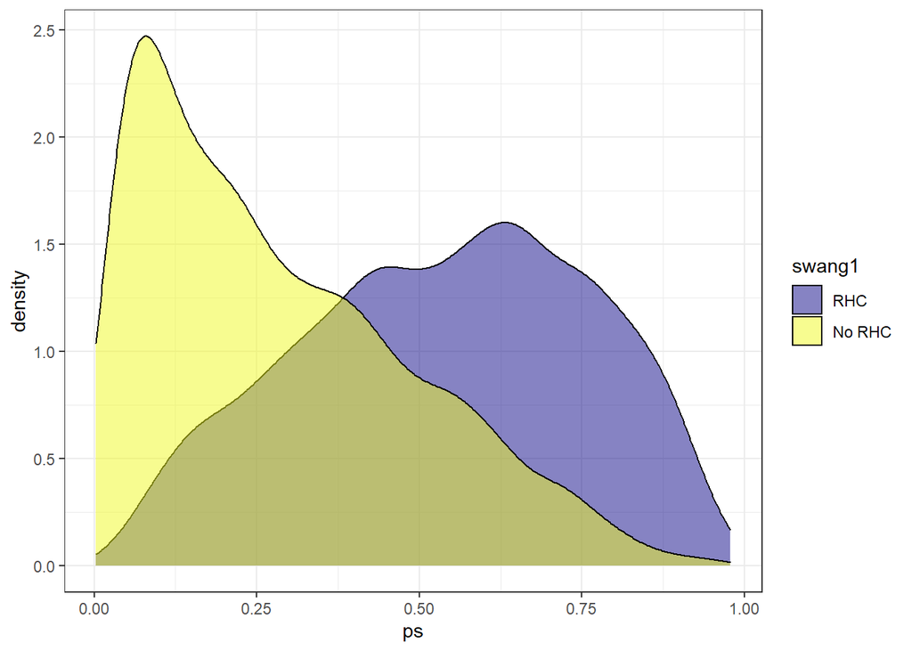

```r
ggplot(rhc, aes(x = ps, fill = swang1)) +
    geom_density(alpha = 0.5) +
    scale_fill_viridis_d(option = "plasma") +
    theme_bw()
```

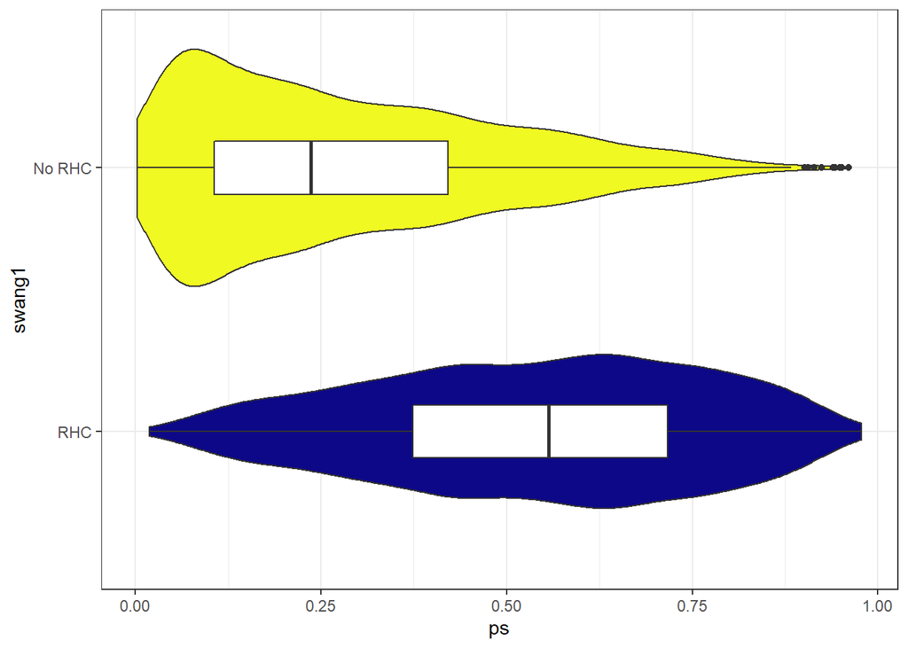

```r
ggplot(rhc, aes(x = swang1, y = ps)) +
    geom_violin(aes(fill = swang1)) +
    geom_boxplot(width = 0.2) +
    scale_fill_viridis_d(option = "plasma") +
    guides(fill = "none") +
    coord_flip() +
    theme_bw()
```

OK. We’re trying to use `ps` to estimate the probability of having a RHC, and it looks the people who actually had RHC have higher PS, on average, so that’s promising.

# 9 Checking Rubin’s Rules Prior to Propensity Adjustment

Rubin Rule 1 result should ideally be near 0, and certainly between -50 and +50.

```r
rubin1.unadj <- with(rhc,
                  abs(100*(mean(linps[swang1=="RHC"]) -
                               mean(linps[swang1=="No RHC"]))/
                          sd(linps)))
rubin1.unadj
```

```
[1] 101.583
```

Rubin Rule 2 result should ideally be near 1, and certainly between 1/2 and 2.

```r
rubin2.unadj <- with(rhc,
                  var(linps[swang1 == "RHC"]) /
                      var(linps[swang1 == "No RHC"]))
rubin2.unadj
```

```
[1] 0.7359463
```

So, we’ve got some work to do. Let’s try matching. In several different ways.

# 10 Match 1: 1:1 Greedy Matching on the linear PS, without Replacement

```r
X <- rhc$linps
Tr <- as.logical(rhc$swang1 == "RHC")
match1 <- Match(Tr = Tr, X = X, M = 1,
                estimand = "ATT", replace = FALSE,
                ties = FALSE)
summary(match1)
```

```
Estimate...  0
SE.........  0
T-stat.....  NaN
p.val......  NA

Original number of observations..............  5735
Original number of treated obs...............  2184
Matched number of observations...............  2184
Matched number of observations  (unweighted).  2184
```

## 10.1 Love Plot for Match 1

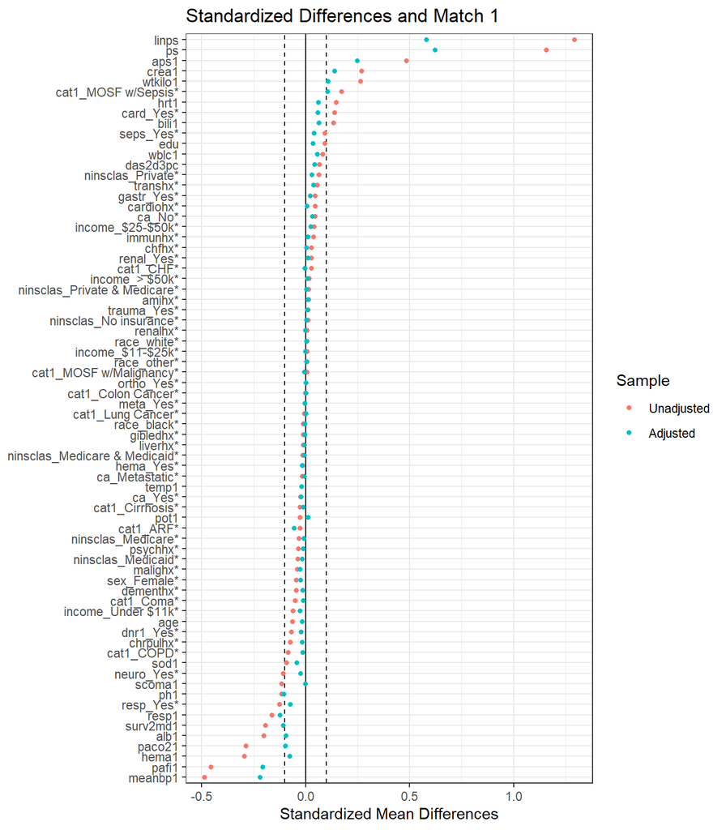

```r
b1 <- bal.tab(match1,
              swang1 == "RHC"  ~
                  age + sex + edu + income + ninsclas + race +
                  cat1 + dnr1 + wtkilo1 + hrt1 + meanbp1 +
                  resp1 + temp1 +
                  card + gastr + hema + meta + neuro + ortho +
                  renal + resp + seps + trauma +
                  amihx + ca + cardiohx + chfhx + chrpulhx +
                  dementhx + gibledhx + immunhx + liverhx +
                  malighx + psychhx + renalhx + transhx +
                  aps1 + das2d3pc + scoma1 + surv2md1 +
                  alb1 + bili1 + crea1 + hema1 + paco21 + pafi1 +
                  ph1 + pot1 + sod1 + wblc1 + ps + linps,
              data=rhc, un = TRUE)

love.plot(b1, threshold = .1, size = 1.5, stars = "raw",
               var.order = "unadjusted",
               title = "Standardized Differences and Match 1") +
    theme_bw()
```

## 10.2 Rubin’s Rules 1 and 2 for Match 1

Create a new data frame, containing only the matched sample.

```r
matches_1 <- factor(rep(match1$index.treated, 2))
rhc.matches_1 <- cbind(matches_1,
          rhc[c(match1$index.control, match1$index.treated),])
```

Rubin Rule 1 result after matching should ideally be near 0, and certainly between -50 and +50.

```r
rubin1.m1 <- with(rhc.matches_1,
                  abs(100*(mean(linps[swang1=="RHC"]) -
                               mean(linps[swang1=="No RHC"]))/
                          sd(linps)))
rubin1.m1
```

```
[1] 61.88315
```

Rubin Rule 2 result after matching should ideally be near 1, and certainly between 1/2 and 2.

```r
rubin2.m1 <- with(rhc.matches_1,
                  var(linps[swang1 == "RHC"]) /
                      var(linps[swang1 == "No RHC"]))
rubin2.m1
```

```
[1] 1.687288
```

# 11 Match 2: 1:2 Greedy Matching on the linear PS, without Replacement

```r
X <- rhc$linps
Tr <- as.logical(rhc$swang1 == "RHC")
match2 <- Match(Tr = Tr, X = X, M = 2,
                estimand = "ATT", replace = FALSE,
                ties = FALSE)
summary(match2)
```

```
Estimate...  0
SE.........  0
T-stat.....  NaN
p.val......  NA

Original number of observations..............  5735
Original number of treated obs...............  2184
Matched number of observations...............  1775
Matched number of observations  (unweighted).  3550
```

## 11.1 Love Plot for Match 2

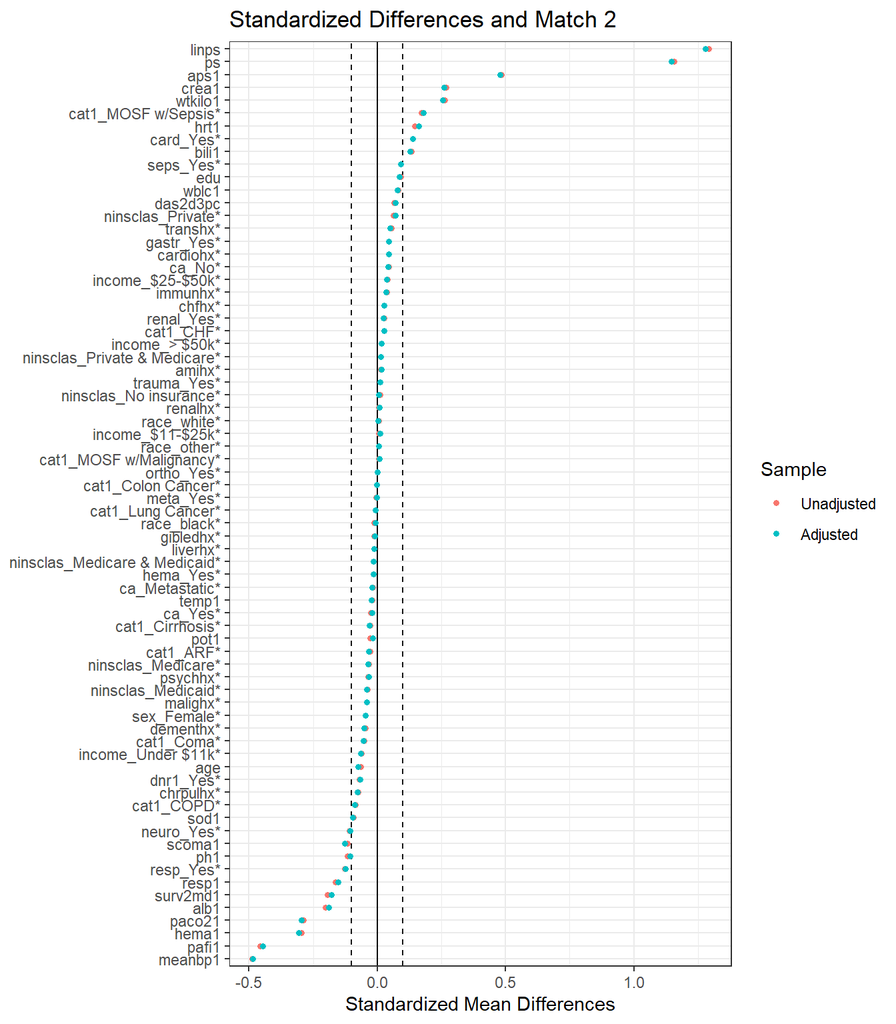

```r
b2 <- bal.tab(match2,
              swang1 == "RHC"  ~
                  age + sex + edu + income + ninsclas + race +
                  cat1 + dnr1 + wtkilo1 + hrt1 + meanbp1 +
                  resp1 + temp1 +
                  card + gastr + hema + meta + neuro + ortho +
                  renal + resp + seps + trauma +
                  amihx + ca + cardiohx + chfhx + chrpulhx +
                  dementhx + gibledhx + immunhx + liverhx +
                  malighx + psychhx + renalhx + transhx +
                  aps1 + das2d3pc + scoma1 + surv2md1 +
                  alb1 + bili1 + crea1 + hema1 + paco21 + pafi1 +
                  ph1 + pot1 + sod1 + wblc1 + ps + linps,
              data=rhc, un = TRUE)

love.plot(b2, threshold = .1, size = 1.5, stars = "raw",
               var.order = "unadjusted",
               title = "Standardized Differences and Match 2") +
    theme_bw()
```

## 11.2 Rubin’s Rules 1 and 2 for Match 2

Create a new data frame, containing only the matched sample.

```r
matches_2 <- factor(rep(match2$index.treated, 2))
rhc.matches_2 <- cbind(matches_2,
          rhc[c(match2$index.control, match2$index.treated),])
```

Rubin Rule 1 result after matching should ideally be near 0, and certainly between -50 and +50.

```r
rubin1.m2 <- with(rhc.matches_2,
                  abs(100*(mean(linps[swang1=="RHC"]) -
                               mean(linps[swang1=="No RHC"]))/
                          sd(linps)))
rubin1.m2
```

```
[1] 101.2148
```

Rubin Rule 2 result after matching should ideally be near 1, and certainly between 1/2 and 2.

```r
rubin2.m2 <- with(rhc.matches_2,
                  var(linps[swang1 == "RHC"]) /
                      var(linps[swang1 == "No RHC"]))
rubin2.m2
```

```
[1] 0.7569187
```

# 12 Match 3: Genetic Search Matching to do 1:1 Matching without replacement

The `GenMatch` function finds optimal balance using multivariate matching where a genetic search algorithm determines the weight that each covariate is given.

Please note that I am using way too small values of `pop.size` (especially) and probably `max.generations`, too, so that things run quickly. I am also only matching on the propensity score and linear propensity score, rather than on the individual covariates. For a course project, I recommend you try matching on the individual covariates if you can, but this reduction in the paramater values is fine.

For actual publications, follow the recommendations of the `GenMatch` algorithm, as described in the `Matching` and `genoud` package help files. The default values (which may be too small themselves) are 100 for both `pop.size` and `max.generations`.

```r
X <- cbind(rhc$linps, rhc$ps)
Tr <- as.logical(rhc$swang1 == "RHC")
genout3 <- GenMatch(Tr = Tr, X = X,
                    estimand = "ATT", M = 1,
                    pop.size = 10, max.generations = 10,
                    wait.generations = 4, verbose = FALSE)
```

[output not shown]

[output cut: 72 more lines]

```
No significant improvement in 4 generations.

Solution Lexical Fitness Value:
1.311405e-01  2.250274e-01  1.000000e+00  1.000000e+00

Parameters at the Solution:

 X[ 1] :    1.182693e+02
 X[ 2] :    8.855767e+02

Solution Found Generation 1
Number of Generations Run 6

Thu Feb 24 16:29:21 2022
Total run time : 0 hours 0 minutes and 23 seconds
```

```r
match3 <- Match(Tr = Tr, X = X, estimand = "ATT",
                 Weight.matrix = genout3)
summary(match3)
```

```
Estimate...  0
SE.........  0
T-stat.....  NaN
p.val......  NA

Original number of observations..............  5735
Original number of treated obs...............  2184
Matched number of observations...............  2184
Matched number of observations  (unweighted).  2259
```

## 12.1 Love Plot for Match 3

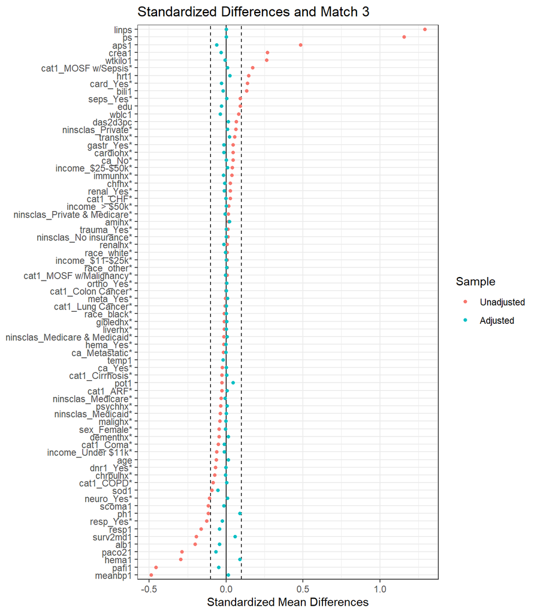

```r
b3 <- bal.tab(match3,
              swang1 == "RHC"  ~
                  age + sex + edu + income + ninsclas + race +
                  cat1 + dnr1 + wtkilo1 + hrt1 + meanbp1 +
                  resp1 + temp1 +
                  card + gastr + hema + meta + neuro + ortho +
                  renal + resp + seps + trauma +
                  amihx + ca + cardiohx + chfhx + chrpulhx +
                  dementhx + gibledhx + immunhx + liverhx +
                  malighx + psychhx + renalhx + transhx +
                  aps1 + das2d3pc + scoma1 + surv2md1 +
                  alb1 + bili1 + crea1 + hema1 + paco21 + pafi1 +
                  ph1 + pot1 + sod1 + wblc1 + ps + linps,
              data=rhc, un = TRUE)

love.plot(b3, threshold = .1, size = 1.5, stars = "raw",
               var.order = "unadjusted",
               title = "Standardized Differences and Match 3") +
    theme_bw()
```

## 12.2 Rubin’s Rules 1 and 2 for Match 3

Create a new data frame, containing only the matched sample.

```r
matches_3 <- factor(rep(match3$index.treated, 2))
rhc.matches_3 <- cbind(matches_3,
          rhc[c(match3$index.control, match3$index.treated),])
```

Rubin Rule 1 result after matching should ideally be near 0, and certainly between -50 and +50.

```r
rubin1.m3 <- with(rhc.matches_3,
                  abs(100*(mean(linps[swang1=="RHC"]) -
                               mean(linps[swang1=="No RHC"]))/
                          sd(linps)))
rubin1.m3
```

```
[1] 0.04940705
```

Rubin Rule 2 result after matching should ideally be near 1, and certainly between 1/2 and 2.

```r
rubin2.m3 <- with(rhc.matches_3,
                  var(linps[swang1 == "RHC"]) /
                      var(linps[swang1 == "No RHC"]))
rubin2.m3
```

```
[1] 1.002561
```

# 13 Match 4: 1:1 Greedy Matching on the linear PS, WITH Replacement

```r
X <- rhc$linps
Tr <- as.logical(rhc$swang1 == "RHC")
match4 <- Match(Tr = Tr, X = X, M = 1,
                estimand = "ATT", replace = TRUE,
                ties = FALSE)
summary(match4)
```

```
Estimate...  0
SE.........  0
T-stat.....  NaN
p.val......  NA

Original number of observations..............  5735
Original number of treated obs...............  2184
Matched number of observations...............  2184
Matched number of observations  (unweighted).  2184
```

## 13.1 Love Plot for Match 4

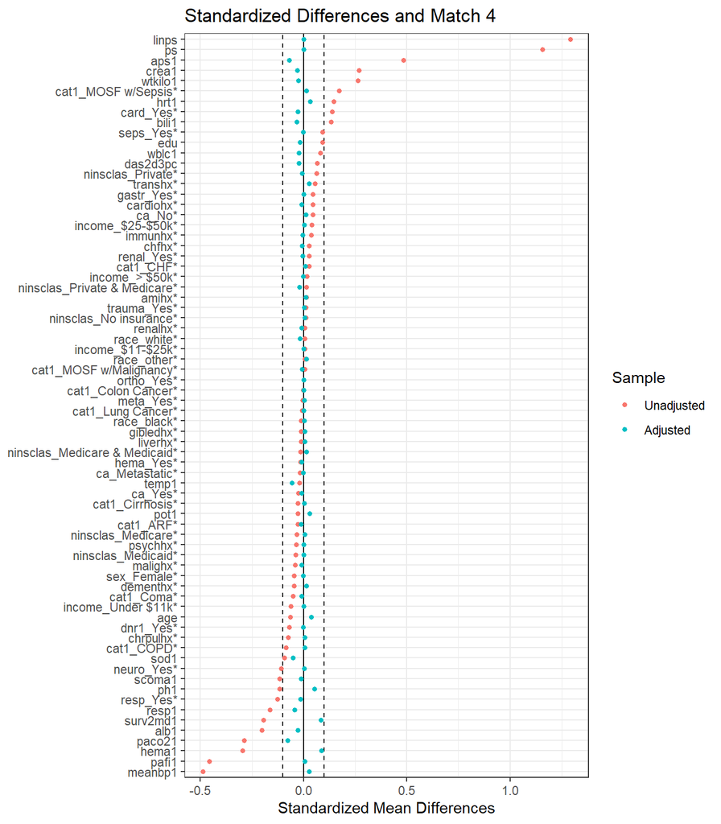

```r
b4 <- bal.tab(match4,
              swang1 == "RHC"  ~
                  age + sex + edu + income + ninsclas + race +
                  cat1 + dnr1 + wtkilo1 + hrt1 + meanbp1 +
                  resp1 + temp1 +
                  card + gastr + hema + meta + neuro + ortho +
                  renal + resp + seps + trauma +
                  amihx + ca + cardiohx + chfhx + chrpulhx +
                  dementhx + gibledhx + immunhx + liverhx +
                  malighx + psychhx + renalhx + transhx +
                  aps1 + das2d3pc + scoma1 + surv2md1 +
                  alb1 + bili1 + crea1 + hema1 + paco21 + pafi1 +
                  ph1 + pot1 + sod1 + wblc1 + ps + linps,
              data=rhc, un = TRUE)

love.plot(b4, threshold = .1, size = 1.5, stars = "raw",
               var.order = "unadjusted",
               title = "Standardized Differences and Match 4") +
    theme_bw()
```

## 13.2 Rubin’s Rules 1 and 2 for Match 4

Create a new data frame, containing only the matched sample.

```r
matches_4 <- factor(rep(match4$index.treated, 2))
rhc.matches_4 <- cbind(matches_4,
          rhc[c(match4$index.control, match4$index.treated),])
```

Rubin Rule 1 result after matching should ideally be near 0, and certainly between -50 and +50.

```r
rubin1.m4 <- with(rhc.matches_4,
                  abs(100*(mean(linps[swang1=="RHC"]) -
                               mean(linps[swang1=="No RHC"]))/
                          sd(linps)))
rubin1.m4
```

```
[1] 0.05521448
```

Rubin Rule 2 result after matching should ideally be near 1, and certainly between 1/2 and 2.

```r
rubin2.m4 <- with(rhc.matches_4,
                  var(linps[swang1 == "RHC"]) /
                      var(linps[swang1 == "No RHC"]))
rubin2.m4
```

```
[1] 1.002868
```

# 14 Match 5: 1:1 Caliper Matching on the linear PS, WITHOUT Replacement

```r
X <- rhc$linps
Tr <- as.logical(rhc$swang1 == "RHC")
match5 <- Match(Tr = Tr, X = X, M = 1,
                caliper = 0.2,
                estimand = "ATT", replace = FALSE,
                ties = FALSE)
summary(match5)
```

```
Estimate...  0
SE.........  0
T-stat.....  NaN
p.val......  NA

Original number of observations..............  5735
Original number of treated obs...............  2184
Matched number of observations...............  1563
Matched number of observations  (unweighted).  1563

Caliper (SDs)........................................   0.2
Number of obs dropped by 'exact' or 'caliper'  621
```

## 14.1 Love Plot for Match 5

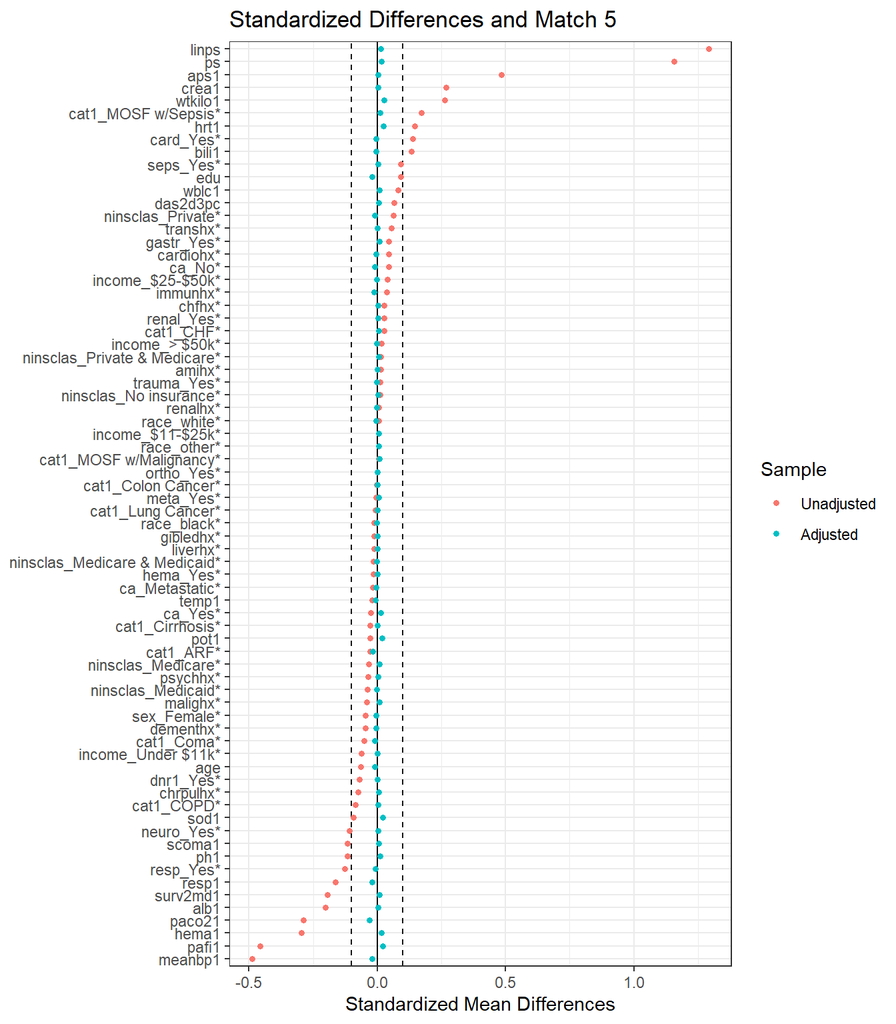

```r
b5 <- bal.tab(match5,
              swang1 == "RHC"  ~
                  age + sex + edu + income + ninsclas + race +
                  cat1 + dnr1 + wtkilo1 + hrt1 + meanbp1 +
                  resp1 + temp1 +
                  card + gastr + hema + meta + neuro + ortho +
                  renal + resp + seps + trauma +
                  amihx + ca + cardiohx + chfhx + chrpulhx +
                  dementhx + gibledhx + immunhx + liverhx +
                  malighx + psychhx + renalhx + transhx +
                  aps1 + das2d3pc + scoma1 + surv2md1 +
                  alb1 + bili1 + crea1 + hema1 + paco21 + pafi1 +
                  ph1 + pot1 + sod1 + wblc1 + ps + linps,
              data=rhc, un = TRUE)

love.plot(b5, threshold = .1, size = 1.5, stars = "raw",
               var.order = "unadjusted",
               title = "Standardized Differences and Match 5") +
    theme_bw()
```

## 14.2 Rubin’s Rules 1 and 2 for Match 5

Create a new data frame, containing only the matched sample.

```r
matches_5 <- factor(rep(match5$index.treated, 2))
rhc.matches_5 <- cbind(matches_5,
          rhc[c(match5$index.control, match5$index.treated),])
```

Rubin Rule 1 result after matching should ideally be near 0, and certainly between -50 and +50.

```r
rubin1.m5 <- with(rhc.matches_5,
                  abs(100*(mean(linps[swang1=="RHC"]) -
                               mean(linps[swang1=="No RHC"]))/
                          sd(linps)))
rubin1.m5
```

```
[1] 1.697439
```

Rubin Rule 2 result after matching should ideally be near 1, and certainly between 1/2 and 2.

```r
rubin2.m5 <- with(rhc.matches_5,
                  var(linps[swang1 == "RHC"]) /
                      var(linps[swang1 == "No RHC"]))
rubin2.m5
```

```
[1] 1.027527
```

# 15 Match 6: 1:2 Greedy Matching on the linear PS, WITH Replacement

```r
X <- rhc$linps
Tr <- as.logical(rhc$swang1 == "RHC")
match6 <- Match(Tr = Tr, X = X, M = 2,
                estimand = "ATT", replace = TRUE,
                ties = FALSE)
summary(match6)
```

```
Estimate...  0
SE.........  0
T-stat.....  NaN
p.val......  NA

Original number of observations..............  5735
Original number of treated obs...............  2184
Matched number of observations...............  2184
Matched number of observations  (unweighted).  4368
```

## 15.1 Love Plot for Match 6

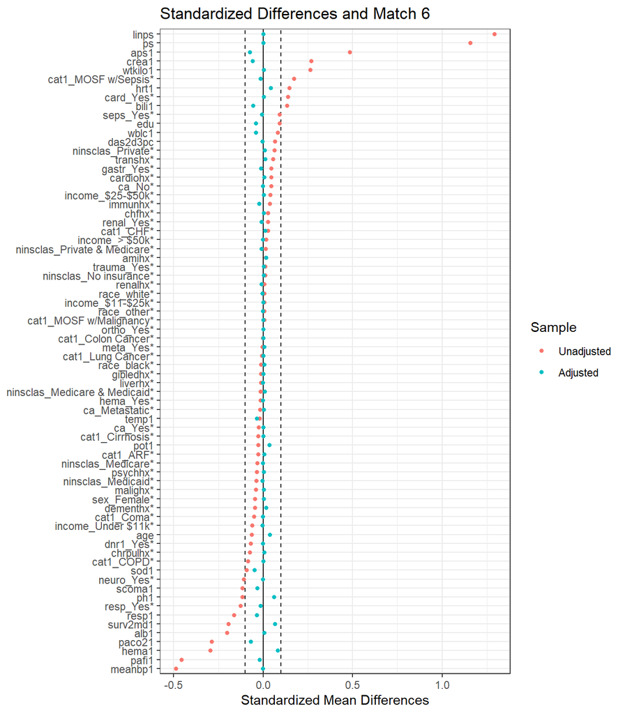

```r
b6 <- bal.tab(match6,
              swang1 == "RHC"  ~
                  age + sex + edu + income + ninsclas + race +
                  cat1 + dnr1 + wtkilo1 + hrt1 + meanbp1 +
                  resp1 + temp1 +
                  card + gastr + hema + meta + neuro + ortho +
                  renal + resp + seps + trauma +
                  amihx + ca + cardiohx + chfhx + chrpulhx +
                  dementhx + gibledhx + immunhx + liverhx +
                  malighx + psychhx + renalhx + transhx +
                  aps1 + das2d3pc + scoma1 + surv2md1 +
                  alb1 + bili1 + crea1 + hema1 + paco21 + pafi1 +
                  ph1 + pot1 + sod1 + wblc1 + ps + linps,
              data=rhc, un = TRUE)

love.plot(b6, threshold = .1, size = 1.5, stars = "raw",
               var.order = "unadjusted",
               title = "Standardized Differences and Match 6") +
    theme_bw()
```

## 15.2 Rubin’s Rules 1 and 2 for Match 6

Create a new data frame, containing only the matched sample.

```r
matches_6 <- factor(rep(match6$index.treated, 2))
rhc.matches_6 <- cbind(matches_6,
          rhc[c(match6$index.control, match6$index.treated),])
```

Rubin Rule 1 result after matching should ideally be near 0, and certainly between -50 and +50.

```r
rubin1.m6 <- with(rhc.matches_6,
                  abs(100*(mean(linps[swang1=="RHC"]) -
                               mean(linps[swang1=="No RHC"]))/
                          sd(linps)))
rubin1.m6
```

```
[1] 0.1186399
```

Rubin Rule 2 result after matching should ideally be near 1, and certainly between 1/2 and 2.

```r
rubin2.m6 <- with(rhc.matches_6,
                  var(linps[swang1 == "RHC"]) /
                      var(linps[swang1 == "No RHC"]))
rubin2.m6
```

```
[1] 1.005432
```

# 16 Ranking the Matches

[output not shown]

# 17 ATT Matching Estimates for the Binary Outcome, Death

## 17.1 With Match 1, in detail

Note that the variable which identifies the matches (called `matches_1`) is set up as a factor, as it needs to be, and that I’m using the 1/0 versions of both the outcome (so `died` rather than `death`) and treatment (so `treat_rhc` rather than `swang1`).

```r
death_adj_m1 <- clogit(died ~ treat_rhc + strata(matches_1), data = rhc.matches_1)

summary(death_adj_m1)
```

```
Call:
coxph(formula = Surv(rep(1, 4368L), died) ~ treat_rhc + strata(matches_1),
    data = rhc.matches_1, method = "exact")

  n= 4368, number of events= 2861

             coef exp(coef) se(coef)     z Pr(>|z|)
treat_rhc 0.23156   1.26056  0.06488 3.569 0.000358 ***
---
Signif. codes:  0 '***' 0.001 '**' 0.01 '*' 0.05 '.' 0.1 ' ' 1

          exp(coef) exp(-coef) lower .95 upper .95
treat_rhc     1.261     0.7933      1.11     1.432

Concordance= 0.558  (se = 0.023 )
Likelihood ratio test= 12.82  on 1 df,   p=3e-04
Wald test            = 12.74  on 1 df,   p=4e-04
Score (logrank) test = 12.79  on 1 df,   p=3e-04
```

The odds ratio in the `exp(coef)` section above is the average causal effect estimate. It describes the odds of having an event (`died`) occur associated with being a RHC subject (as identified by `treat_rhc`), as compared to the odds of that event when a non-RHC subject. We can tidy this with:

```r
tidy(death_adj_m1, exponentiate = TRUE, conf.level = 0.95)
```

```
# A tibble: 1 x 5
  term      estimate std.error statistic  p.value
  <chr>        <dbl>     <dbl>     <dbl>    <dbl>
1 treat_rhc     1.26    0.0649      3.57 0.000358
```

## 17.2 With Matches 2-6, in much less detail

```r
death_adj_m2 <- clogit(died ~ treat_rhc + strata(matches_2), data = rhc.matches_2)
tidy(death_adj_m2, exponentiate = TRUE, conf.level = 0.95)
```

```
# A tibble: 1 x 5
  term      estimate std.error statistic     p.value
  <chr>        <dbl>     <dbl>     <dbl>       <dbl>
1 treat_rhc     1.33    0.0548      5.27 0.000000137
```

```r
death_adj_m3 <- clogit(died ~ treat_rhc + strata(matches_3), data = rhc.matches_3)
tidy(death_adj_m3, exponentiate = TRUE, conf.level = 0.95)
```

```
# A tibble: 1 x 5
  term      estimate std.error statistic   p.value
  <chr>        <dbl>     <dbl>     <dbl>     <dbl>
1 treat_rhc     1.32    0.0634      4.35 0.0000137
```

```r
death_adj_m4 <- clogit(died ~ treat_rhc + strata(matches_4), data = rhc.matches_4)
tidy(death_adj_m4, exponentiate = TRUE, conf.level = 0.95)
```

```
# A tibble: 1 x 5
  term      estimate std.error statistic p.value
  <chr>        <dbl>     <dbl>     <dbl>   <dbl>
1 treat_rhc     1.23    0.0636      3.22 0.00127
```

```r
death_adj_m5 <- clogit(died ~ treat_rhc + strata(matches_5), data = rhc.matches_5)
tidy(death_adj_m5, exponentiate = TRUE, conf.level = 0.95)
```

```
# A tibble: 1 x 5
  term      estimate std.error statistic  p.value
  <chr>        <dbl>     <dbl>     <dbl>    <dbl>
1 treat_rhc     1.33    0.0754      3.76 0.000170
```

```r
death_adj_m6 <- clogit(died ~ treat_rhc + strata(matches_6), data = rhc.matches_6)
tidy(death_adj_m6, exponentiate = TRUE, conf.level = 0.95)
```

```
# A tibble: 1 x 5
  term      estimate std.error statistic  p.value
  <chr>        <dbl>     <dbl>     <dbl>    <dbl>
1 treat_rhc     1.36    0.0491      6.25 4.18e-10
```

## 17.3 Graphing the Results Across Multiple Matching Strategies

```r
temp0 <- tidy(death_unadj, conf.int = TRUE, exponentiate = TRUE) %>%
    filter(term == "treat_rhc")
temp1 <- tidy(death_adj_m1, exponentiate = TRUE, conf.int = T, conf.level = 0.95)
temp2 <- tidy(death_adj_m2, exponentiate = TRUE, conf.int = T, conf.level = 0.95)
temp3 <- tidy(death_adj_m3, exponentiate = TRUE, conf.int = T, conf.level = 0.95)
temp4 <- tidy(death_adj_m4, exponentiate = TRUE, conf.int = T, conf.level = 0.95)
temp5 <- tidy(death_adj_m5, exponentiate = TRUE, conf.int = T, conf.level = 0.95)
temp6 <- tidy(death_adj_m6, exponentiate = TRUE, conf.int = T, conf.level = 0.95)

death_match_results <- rbind(temp0, temp1, temp2, temp3, temp4, temp5, temp6)

death_match_results <- death_match_results %>%
    mutate(approach = c("Unmatched", "Match 1", "Match 2", "Match 3", "Match 4", "Match 5", "Match 6")) %>%
    mutate(description = c("No Matching", "1:1 greedy matching without replacement",
                           "1:2 greedy matching without replacement",
                           "1:1 genetic search matching without replacement",
                           "1:1 greedy matching with replacement",
                           "1:1 caliper matching on the linear PS without replacement",
                           "1:2 greedy matching with replacement"))

death_match_results
```

```
# A tibble: 7 x 9
  term      estimate std.error statistic  p.value conf.low conf.high approach
  <chr>        <dbl>     <dbl>     <dbl>    <dbl>    <dbl>     <dbl> <chr>
1 treat_rhc     1.25    0.0576      3.90 9.43e- 5     1.12      1.40 Unmatched
2 treat_rhc     1.26    0.0649      3.57 3.58e- 4     1.11      1.43 Match 1
3 treat_rhc     1.33    0.0548      5.27 1.37e- 7     1.20      1.49 Match 2
4 treat_rhc     1.32    0.0634      4.35 1.37e- 5     1.16      1.49 Match 3
5 treat_rhc     1.23    0.0636      3.22 1.27e- 3     1.08      1.39 Match 4
6 treat_rhc     1.33    0.0754      3.76 1.70e- 4     1.15      1.54 Match 5
7 treat_rhc     1.36    0.0491      6.25 4.18e-10     1.23      1.50 Match 6
# ... with 1 more variable: description <chr>
```

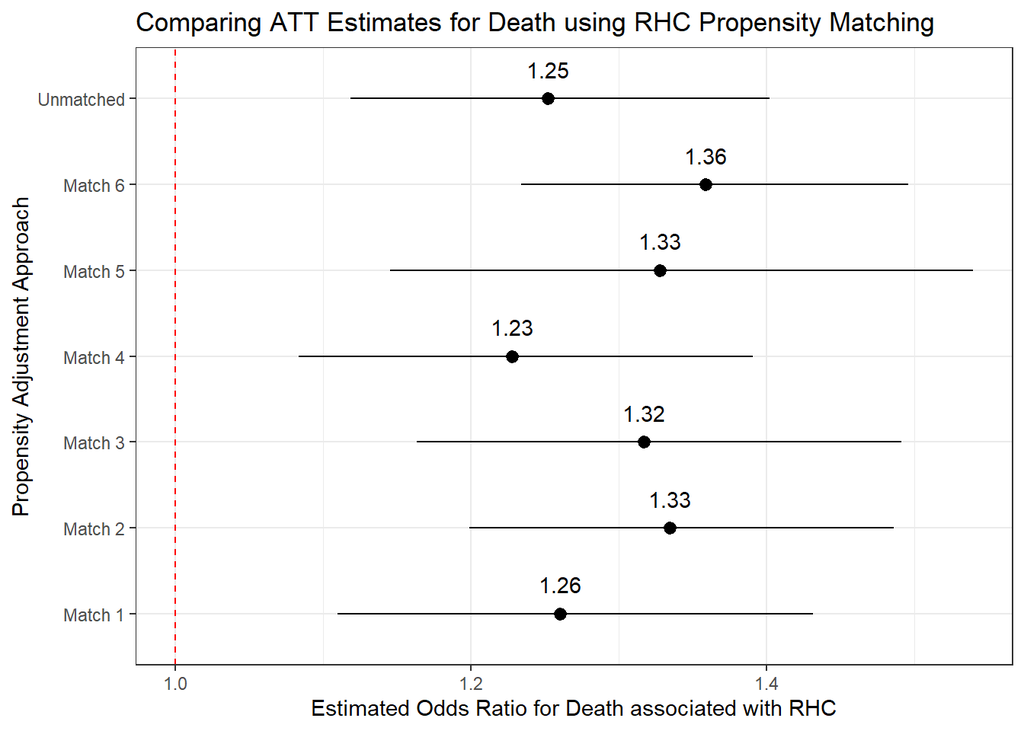

```r
ggplot(death_match_results, aes(x = approach, y = estimate, ymin = conf.low, ymax = conf.high)) +
    geom_text(aes(label = round_half_up(estimate,2)), vjust = -1.25) +
    geom_pointrange() +
    geom_hline(yintercept = 1, col = "red", linetype = "dashed") +
    theme_bw() +
    coord_flip() +
    labs(title = "Comparing ATT Estimates for Death using RHC Propensity Matching",
         x = "Propensity Adjustment Approach",
         y = "Estimated Odds Ratio for Death associated with RHC")
```

Let’s look at just the four strategies that achieved stronger balance.

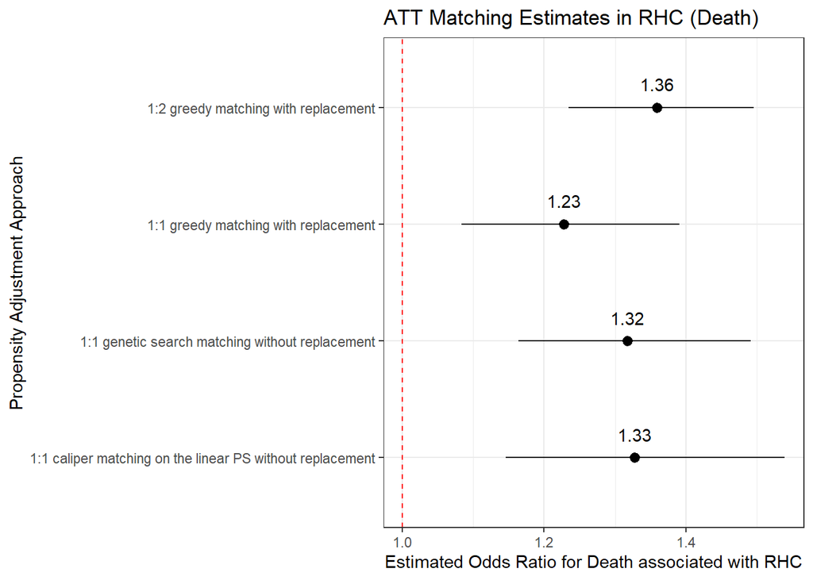

```r
death_match_results %>%
    filter(approach %in% c("Match 3", "Match 4", "Match 5", "Match 6")) %>%
ggplot(., aes(x = description, y = estimate, ymin = conf.low, ymax = conf.high)) +
    geom_text(aes(label = round_half_up(estimate,2)), vjust = -1.25) +
    geom_pointrange() +
    geom_hline(yintercept = 1, col = "red", linetype = "dashed") +
    theme_bw() +
    coord_flip() +
    labs(title = "ATT Matching Estimates in RHC (Death)",
         x = "Propensity Adjustment Approach",
         y = "Estimated Odds Ratio for Death associated with RHC")
```

# 18 ATT Matching Estimates for the Quantitative Outcome, Hospital Length of Stay

## 18.1 With Match 1, in detail

Again, the variable which identifies the matches (called `matches_1`) is set up as a factor, as it needs to be, and that I’m using the 1/0 version of treatment (so `treat_rhc` rather than `swang1`).

Our result for this quantitative outcome (`hospdays`) comes from a mixed model where the matches are treated as a random factor, but the treatment group is treated as a fixed factor, using the `lme4` package.

```r
hospdays_adj_m1 <- lmer(hospdays ~ treat_rhc + (1 | matches_1),
                        data = rhc.matches_1)

summary(hospdays_adj_m1); confint(hospdays_adj_m1)
```

```
Linear mixed model fit by REML ['lmerMod']
Formula: hospdays ~ treat_rhc + (1 | matches_1)
   Data: rhc.matches_1

REML criterion at convergence: 40934.5

Scaled residuals:
    Min      1Q  Median      3Q     Max
-0.9292 -0.5540 -0.3137  0.1747 11.9768

Random effects:
 Groups    Name        Variance Std.Dev.
 matches_1 (Intercept)  14.5     3.809
 Residual              674.0    25.962
Number of obs: 4368, groups:  matches_1, 2184

Fixed effects:
            Estimate Std. Error t value
(Intercept)  20.8255     0.5615  37.090
treat_rhc     3.8658     0.7857   4.921

Correlation of Fixed Effects:
          (Intr)
treat_rhc -0.700
```

```
Computing profile confidence intervals ...
```

```
                2.5 %    97.5 %
.sig01       0.000000  6.594183
.sigma      25.205111 26.717184
(Intercept) 19.725069 21.926030
treat_rhc    2.325669  5.406016
```

The estimated effect of `treat_rhc` in the fixed effects section, combined with the 95% confidence intervals material, provides the average causal effect estimate. It describes the change in the outcome `hospdays` associated with being a RHC subject (as identified by `treat_rhc`), as compared to being a non-RHC subject. We can tidy this with:

```r
broom.mixed::tidy(hospdays_adj_m1, conf.int = TRUE, conf.level = 0.95)
```

```
# A tibble: 4 x 8
  effect   group     term        estimate std.error statistic conf.low conf.high
  <chr>    <chr>     <chr>          <dbl>     <dbl>     <dbl>    <dbl>     <dbl>
1 fixed    <NA>      (Intercept)    20.8      0.561     37.1     19.7      21.9
2 fixed    <NA>      treat_rhc       3.87     0.786      4.92     2.33      5.41
3 ran_pars matches_1 sd__(Inter~     3.81    NA         NA       NA        NA
4 ran_pars Residual  sd__Observ~    26.0     NA         NA       NA        NA
```

or more specifically, we can look at just the treatment effect with:

```r
broom.mixed::tidy(hospdays_adj_m1, conf.int = TRUE, conf.level = 0.95) %>%
    filter(term == "treat_rhc")
```

```
# A tibble: 1 x 8
  effect group term      estimate std.error statistic conf.low conf.high
  <chr>  <chr> <chr>        <dbl>     <dbl>     <dbl>    <dbl>     <dbl>
1 fixed  <NA>  treat_rhc     3.87     0.786      4.92     2.33      5.41
```

## 18.2 With Matches 2-6, in much less detail

```r
hospdays_adj_m2 <- lmer(hospdays ~ treat_rhc + (1 | matches_2),
                        data = rhc.matches_2)
broom.mixed::tidy(hospdays_adj_m2, conf.int = TRUE, conf.level = 0.95) %>%
    filter(term == "treat_rhc")
```

```
# A tibble: 1 x 8
  effect group term      estimate std.error statistic conf.low conf.high
  <chr>  <chr> <chr>        <dbl>     <dbl>     <dbl>    <dbl>     <dbl>
1 fixed  <NA>  treat_rhc     4.98     0.545      9.14     3.91      6.05
```

```r
hospdays_adj_m3 <- lmer(hospdays ~ treat_rhc + (1 | matches_3),
                        data = rhc.matches_3)
broom.mixed::tidy(hospdays_adj_m3, conf.int = TRUE, conf.level = 0.95) %>%
    filter(term == "treat_rhc")
```

```
# A tibble: 1 x 8
  effect group term      estimate std.error statistic conf.low conf.high
  <chr>  <chr> <chr>        <dbl>     <dbl>     <dbl>    <dbl>     <dbl>
1 fixed  <NA>  treat_rhc     1.41     0.842      1.68   -0.240      3.06
```

```r
hospdays_adj_m4 <- lmer(hospdays ~ treat_rhc + (1 | matches_4),
                        data = rhc.matches_4)
```

```
boundary (singular) fit: see help('isSingular')
```

```r
broom.mixed::tidy(hospdays_adj_m4, conf.int = TRUE, conf.level = 0.95) %>%
    filter(term == "treat_rhc")
```

```
# A tibble: 1 x 8
  effect group term      estimate std.error statistic conf.low conf.high
  <chr>  <chr> <chr>        <dbl>     <dbl>     <dbl>    <dbl>     <dbl>
1 fixed  <NA>  treat_rhc     1.27     0.859      1.48   -0.411      2.96
```

```r
hospdays_adj_m5 <- lmer(hospdays ~ treat_rhc + (1 | matches_5),
                        data = rhc.matches_5)
```

```
boundary (singular) fit: see help('isSingular')
```

```r
broom.mixed::tidy(hospdays_adj_m5, conf.int = TRUE, conf.level = 0.95) %>%
    filter(term == "treat_rhc")
```

```
# A tibble: 1 x 8
  effect group term      estimate std.error statistic conf.low conf.high
  <chr>  <chr> <chr>        <dbl>     <dbl>     <dbl>    <dbl>     <dbl>
1 fixed  <NA>  treat_rhc     2.30     0.919      2.50    0.496      4.10
```

```r
hospdays_adj_m6 <- lmer(hospdays ~ treat_rhc + (1 | matches_6),
                        data = rhc.matches_6)
broom.mixed::tidy(hospdays_adj_m6, conf.int = TRUE, conf.level = 0.95) %>%
    filter(term == "treat_rhc")
```

```
# A tibble: 1 x 8
  effect group term      estimate std.error statistic conf.low conf.high
  <chr>  <chr> <chr>        <dbl>     <dbl>     <dbl>    <dbl>     <dbl>
1 fixed  <NA>  treat_rhc     1.22     0.556      2.18    0.125      2.31
```

## 18.3 Graphing the Results Across Multiple Matching Strategies

```r
temp0 <- tidy(hospdays_unadj, conf.int = TRUE) %>%
    filter(term == "treat_rhc") %>%
    select(term, estimate, std.error, conf.low, conf.high)

temp1 <- tidy(hospdays_adj_m1, conf.int = TRUE, conf.level = 0.95) %>%
    filter(term == "treat_rhc") %>%
    select(term, estimate, std.error, conf.low, conf.high)

temp2 <- tidy(hospdays_adj_m2, conf.int = TRUE, conf.level = 0.95) %>%
    filter(term == "treat_rhc") %>%
    select(term, estimate, std.error, conf.low, conf.high)

temp3 <- tidy(hospdays_adj_m3, conf.int = TRUE, conf.level = 0.95) %>%
    filter(term == "treat_rhc") %>%
    select(term, estimate, std.error, conf.low, conf.high)

temp4 <- tidy(hospdays_adj_m4, conf.int = TRUE, conf.level = 0.95) %>%
    filter(term == "treat_rhc") %>%
    select(term, estimate, std.error, conf.low, conf.high)

temp5 <- tidy(hospdays_adj_m5, conf.int = TRUE, conf.level = 0.95) %>%
    filter(term == "treat_rhc") %>%
    select(term, estimate, std.error, conf.low, conf.high)

temp6 <- tidy(hospdays_adj_m6, conf.int = TRUE, conf.level = 0.95) %>%
    filter(term == "treat_rhc") %>%
    select(term, estimate, std.error, conf.low, conf.high)

hospdays_match_results <- rbind(temp0, temp1, temp2, temp3, temp4, temp5, temp6)

hospdays_match_results <- hospdays_match_results %>%
    mutate(approach = c("Unmatched", "Match 1", "Match 2", "Match 3", "Match 4", "Match 5", "Match 6")) %>%
    mutate(description = c("No Matching", "1:1 greedy matching without replacement",
                           "1:2 greedy matching without replacement",
                           "1:1 genetic search matching without replacement",
                           "1:1 greedy matching with replacement",
                           "1:1 caliper matching on the linear PS without replacement",
                           "1:2 greedy matching with replacement"))

hospdays_match_results
```

```
# A tibble: 7 x 7
  term      estimate std.error conf.low conf.high approach  description
  <chr>        <dbl>     <dbl>    <dbl>     <dbl> <chr>     <chr>
1 treat_rhc     5.16     0.687    3.81       6.51 Unmatched No Matching
2 treat_rhc     3.87     0.786    2.33       5.41 Match 1   1:1 greedy matching~
3 treat_rhc     4.98     0.545    3.91       6.05 Match 2   1:2 greedy matching~
4 treat_rhc     1.41     0.842   -0.240      3.06 Match 3   1:1 genetic search ~
5 treat_rhc     1.27     0.859   -0.411      2.96 Match 4   1:1 greedy matching~
6 treat_rhc     2.30     0.919    0.496      4.10 Match 5   1:1 caliper matchin~
7 treat_rhc     1.22     0.556    0.125      2.31 Match 6   1:2 greedy matching~
```

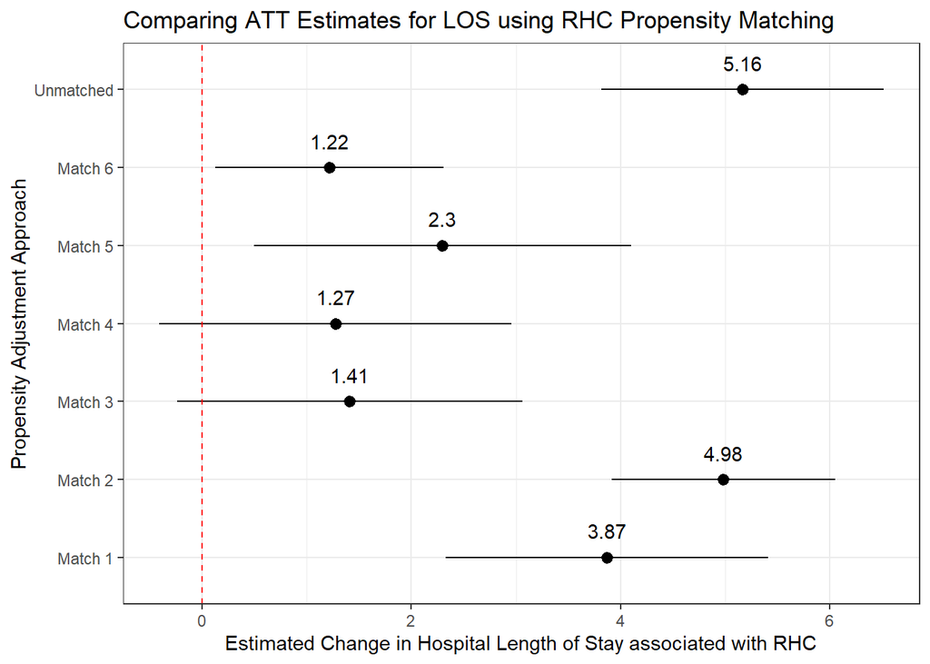

```r
ggplot(hospdays_match_results, aes(x = approach, y = estimate, ymin = conf.low, ymax = conf.high)) +
    geom_text(aes(label = round_half_up(estimate,2)), vjust = -1.25) +
    geom_pointrange() +
    geom_hline(yintercept = 0, col = "red", linetype = "dashed") +
    theme_bw() +
    coord_flip() +
    labs(title = "Comparing ATT Estimates for LOS using RHC Propensity Matching",
         x = "Propensity Adjustment Approach",
         y = "Estimated Change in Hospital Length of Stay associated with RHC")
```

Let’s look at just the four strategies that achieved stronger balance.

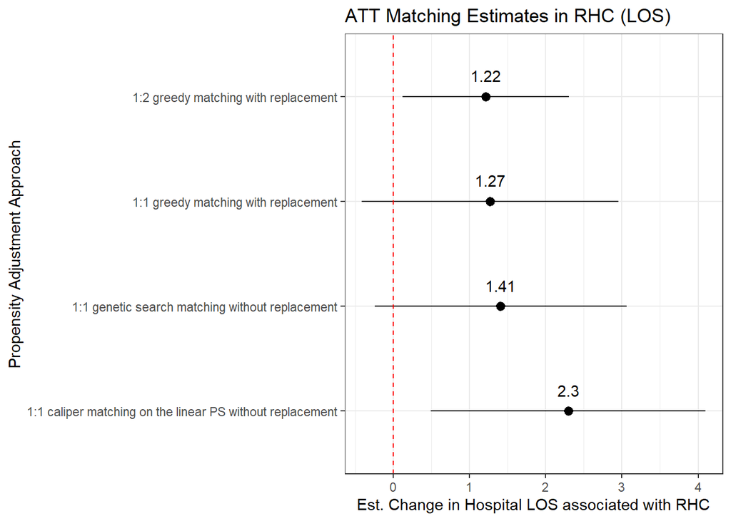

```r
hospdays_match_results %>%
    filter(approach %in% c("Match 3", "Match 4", "Match 5", "Match 6")) %>%
ggplot(., aes(x = description, y = estimate, ymin = conf.low, ymax = conf.high)) +
    geom_text(aes(label = round_half_up(estimate,2)), vjust = -1.25) +
    geom_pointrange() +
    geom_hline(yintercept = 0, col = "red", linetype = "dashed") +
    theme_bw() +
    coord_flip() +
    labs(title = "ATT Matching Estimates in RHC (LOS)",
         x = "Propensity Adjustment Approach",
         y = "Est. Change in Hospital LOS associated with RHC")
```

# 19 ATT Matching Estimates for the Time-to-Event Outcome, In-Study Survival

We’ll use a stratified Cox proportional hazards model to compare the RHC/No RHC groups on our time-to-event outcome `survdays`, while accounting for the matched pairs. The main result will be a relative hazard rate estimate, with 95% CI. I will use the 0/1 numeric versions of the event indicator (`died`), and of the treatment indicator (`treat_rhc`).

## 19.1 With Match 1, in detail

```r
survdays_adj_m1 <- coxph(Surv(survdays, died) ~ treat_rhc + strata(matches_1), data=rhc.matches_1)
summary(survdays_adj_m1)
```

```
Call:
coxph(formula = Surv(survdays, died) ~ treat_rhc + strata(matches_1),
    data = rhc.matches_1)

  n= 4368, number of events= 2861

             coef exp(coef) se(coef)     z Pr(>|z|)
treat_rhc 0.04768   1.04883  0.04554 1.047    0.295

          exp(coef) exp(-coef) lower .95 upper .95
treat_rhc     1.049     0.9534    0.9593     1.147

Concordance= 0.512  (se = 0.016 )
Likelihood ratio test= 1.1  on 1 df,   p=0.3
Wald test            = 1.1  on 1 df,   p=0.3
Score (logrank) test = 1.1  on 1 df,   p=0.3
```

The hazard ratio in the `exp(coef)` section is the average causal effect estimate. It describes the hazard for having an event (`died`) occur associated with being a RHC subject (as identified by `treat_rhc`), as compared to the hazard of that event when a non-RHC subject. We can tidy this with:

```r
tidy(survdays_adj_m1, exponentiate = TRUE, conf.int = TRUE, conf.level = 0.95)
```

```
# A tibble: 1 x 7
  term      estimate std.error statistic p.value conf.low conf.high
  <chr>        <dbl>     <dbl>     <dbl>   <dbl>    <dbl>     <dbl>
1 treat_rhc     1.05    0.0455      1.05   0.295    0.959      1.15
```

## 19.2 With Matches 2-6, in much less detail

```r
survdays_adj_m2 <- coxph(Surv(survdays, died) ~ treat_rhc + strata(matches_2), data=rhc.matches_2)
tidy(survdays_adj_m2, exponentiate = TRUE, conf.int = TRUE, conf.level = 0.95)
```

```
# A tibble: 1 x 7
  term      estimate std.error statistic  p.value conf.low conf.high
  <chr>        <dbl>     <dbl>     <dbl>    <dbl>    <dbl>     <dbl>
1 treat_rhc     1.27    0.0343      7.02 2.17e-12     1.19      1.36
```

```r
survdays_adj_m3 <- coxph(Surv(survdays, died) ~ treat_rhc + strata(matches_3), data=rhc.matches_3)
tidy(survdays_adj_m3, exponentiate = TRUE, conf.int = TRUE, conf.level = 0.95)
```

```
# A tibble: 1 x 7
  term      estimate std.error statistic p.value conf.low conf.high
  <chr>        <dbl>     <dbl>     <dbl>   <dbl>    <dbl>     <dbl>
1 treat_rhc     1.09    0.0445      2.03  0.0426     1.00      1.19
```

```r
survdays_adj_m4 <- coxph(Surv(survdays, died) ~ treat_rhc + strata(matches_4), data=rhc.matches_4)
tidy(survdays_adj_m4, exponentiate = TRUE, conf.int = TRUE, conf.level = 0.95)
```

```
# A tibble: 1 x 7
  term      estimate std.error statistic p.value conf.low conf.high
  <chr>        <dbl>     <dbl>     <dbl>   <dbl>    <dbl>     <dbl>
1 treat_rhc     1.06    0.0452      1.20   0.231    0.966      1.15
```

```r
survdays_adj_m5 <- coxph(Surv(survdays, died) ~ treat_rhc + strata(matches_5), data=rhc.matches_5)
tidy(survdays_adj_m5, exponentiate = TRUE, conf.int = TRUE, conf.level = 0.95)
```

```
# A tibble: 1 x 7
  term      estimate std.error statistic p.value conf.low conf.high
  <chr>        <dbl>     <dbl>     <dbl>   <dbl>    <dbl>     <dbl>
1 treat_rhc     1.12    0.0535      2.05  0.0399     1.01      1.24
```

```r
survdays_adj_m6 <- coxph(Surv(survdays, died) ~ treat_rhc + strata(matches_6), data=rhc.matches_6)
tidy(survdays_adj_m6, exponentiate = TRUE, conf.int = TRUE, conf.level = 0.95)
```

```
# A tibble: 1 x 7
  term      estimate std.error statistic  p.value conf.low conf.high
  <chr>        <dbl>     <dbl>     <dbl>    <dbl>    <dbl>     <dbl>
1 treat_rhc     1.36    0.0313      9.89 4.68e-23     1.28      1.45
```

## 19.3 Graphing the Results Across Multiple Matching Strategies

```r
temp0 <- tidy(survdays_unadj, conf.int = TRUE, exponentiate = TRUE)

temp1 <- tidy(survdays_adj_m1, exponentiate = TRUE, conf.int = TRUE, conf.level = 0.95)

temp2 <- tidy(survdays_adj_m2, exponentiate = TRUE, conf.int = TRUE, conf.level = 0.95)

temp3 <- tidy(survdays_adj_m3, exponentiate = TRUE, conf.int = TRUE, conf.level = 0.95)

temp4 <- tidy(survdays_adj_m4, exponentiate = TRUE, conf.int = TRUE, conf.level = 0.95)

temp5 <- tidy(survdays_adj_m5, exponentiate = TRUE, conf.int = TRUE, conf.level = 0.95)

temp6 <- tidy(survdays_adj_m6, exponentiate = TRUE, conf.int = TRUE, conf.level = 0.95)


survdays_match_results <- rbind(temp0, temp1, temp2, temp3, temp4, temp5, temp6)

survdays_match_results <- survdays_match_results %>%
    mutate(approach = c("Unmatched", "Match 1", "Match 2", "Match 3", "Match 4", "Match 5", "Match 6")) %>%
    mutate(description = c("No Matching", "1:1 greedy matching without replacement",
                           "1:2 greedy matching without replacement",
                           "1:1 genetic search matching without replacement",
                           "1:1 greedy matching with replacement",
                           "1:1 caliper matching on the linear PS without replacement",
                           "1:2 greedy matching with replacement"))

survdays_match_results
```

```
# A tibble: 7 x 9
  term      estimate std.error statistic  p.value conf.low conf.high approach
  <chr>        <dbl>     <dbl>     <dbl>    <dbl>    <dbl>     <dbl> <chr>
1 treat_rhc     1.08    0.0335      2.34 1.92e- 2    1.01       1.15 Unmatched
2 treat_rhc     1.05    0.0455      1.05 2.95e- 1    0.959      1.15 Match 1
3 treat_rhc     1.27    0.0343      7.02 2.17e-12    1.19       1.36 Match 2
4 treat_rhc     1.09    0.0445      2.03 4.26e- 2    1.00       1.19 Match 3
5 treat_rhc     1.06    0.0452      1.20 2.31e- 1    0.966      1.15 Match 4
6 treat_rhc     1.12    0.0535      2.05 3.99e- 2    1.01       1.24 Match 5
7 treat_rhc     1.36    0.0313      9.89 4.68e-23    1.28       1.45 Match 6
# ... with 1 more variable: description <chr>
```

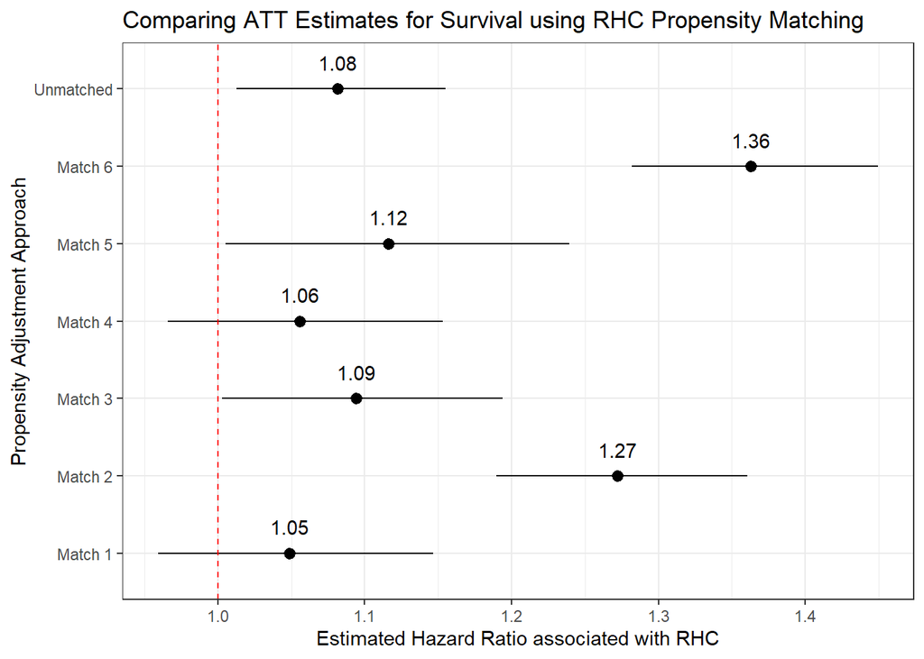

```r
ggplot(survdays_match_results, aes(x = approach, y = estimate, ymin = conf.low, ymax = conf.high)) +
    geom_text(aes(label = round_half_up(estimate,2)), vjust = -1.25) +
    geom_pointrange() +
    geom_hline(yintercept = 1, col = "red", linetype = "dashed") +
    theme_bw() +
    coord_flip() +
    labs(title = "Comparing ATT Estimates for Survival using RHC Propensity Matching",
         x = "Propensity Adjustment Approach",
         y = "Estimated Hazard Ratio associated with RHC")
```

Let’s look at just the four strategies that achieved stronger balance.

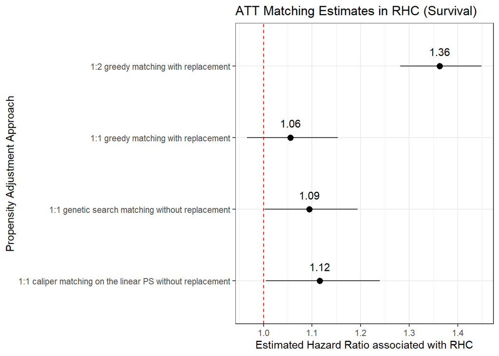

```r
survdays_match_results %>%
    filter(approach %in% c("Match 3", "Match 4", "Match 5", "Match 6")) %>%
ggplot(., aes(x = description, y = estimate, ymin = conf.low, ymax = conf.high)) +
    geom_text(aes(label = round_half_up(estimate,2)), vjust = -1.25) +
    geom_pointrange() +
    geom_hline(yintercept = 1, col = "red", linetype = "dashed") +
    theme_bw() +
    coord_flip() +
    labs(title = "ATT Matching Estimates in RHC (Survival)",
         x = "Propensity Adjustment Approach",
         y = "Estimated Hazard Ratio associated with RHC")
```

# 20 Propensity Score Weighting (ATT approach)

## 20.1 Estimate the Propensity Score using Generalized Boosted Regression, and then perfom ATT Weighting

To begin, we’ll re-estimate the propensity score using the `twang` function `ps`. This uses a *generalized boosted regression* approach to estimate the propensity score and produce material for checking balance.

```r
# Recall that twang does not play well with tibbles,
# so we have to use the data frame version of rhc object
# and I'm using the 1/0 version of the treatment

rhc_df <- base::as.data.frame(rhc)

ps_rhc <- ps(treat_rhc ~
                 age + sex + edu + income + ninsclas +
                 race + cat1 + dnr1 + wtkilo1 + hrt1 +
                 meanbp1 + resp1 + temp1 + card + gastr +
                 hema + meta + neuro + ortho + renal +
                 resp + seps + trauma + amihx + ca +
                 cardiohx + chfhx + chrpulhx + dementhx +
                 gibledhx + immunhx + liverhx + malighx +
                 psychhx + renalhx + transhx + aps1 +
                 das2d3pc + scoma1 + surv2md1 + alb1 +
                 bili1 + crea1 + hema1 + paco21 + pafi1 +
                 ph1 + pot1 + sod1 + wblc1,
             data = rhc_df,
             n.trees = 4000,
             interaction.depth = 2,
             stop.method = c("es.mean"),
             estimand = "ATT",
             verbose = FALSE)
```

### 20.1.1 Did we let the simulations run long enough to stabilize estimates?

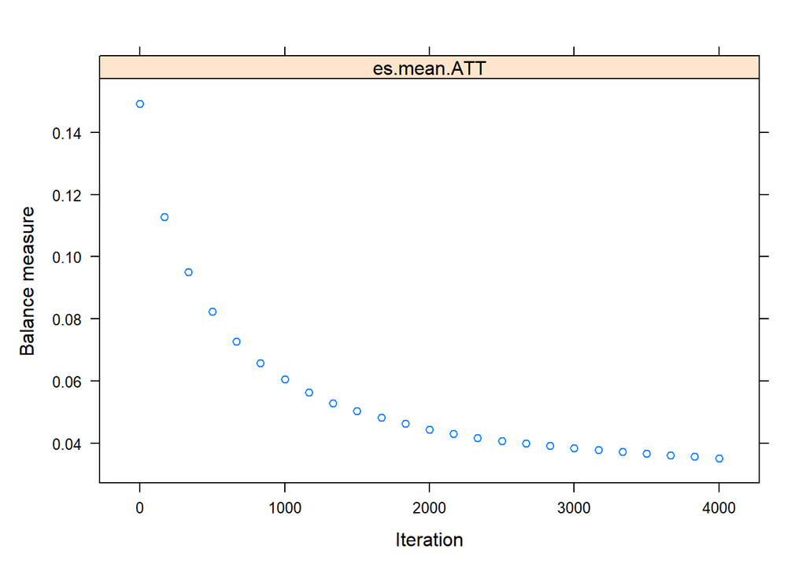

```r
plot(ps_rhc)
```

### 20.1.2 What is the effective sample size of our weighted results?

```r
summary(ps_rhc)
```

```
            n.treat n.ctrl ess.treat ess.ctrl     max.es    mean.es     max.ks
unw            2184   3551      2184 3551.000 0.53367192 0.14968341 0.21274111
es.mean.ATT    2184   3551      2184 1250.501 0.09123789 0.03520429 0.04966016
            max.ks.p    mean.ks iter
unw               NA 0.05831639   NA
es.mean.ATT       NA 0.01540652 3999
```

### 20.1.3 How is the balance?

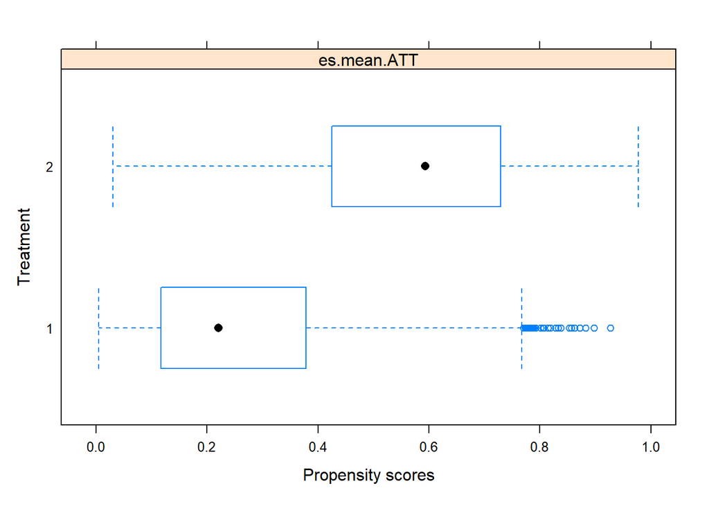

```r
plot(ps_rhc, plots = 2)
```

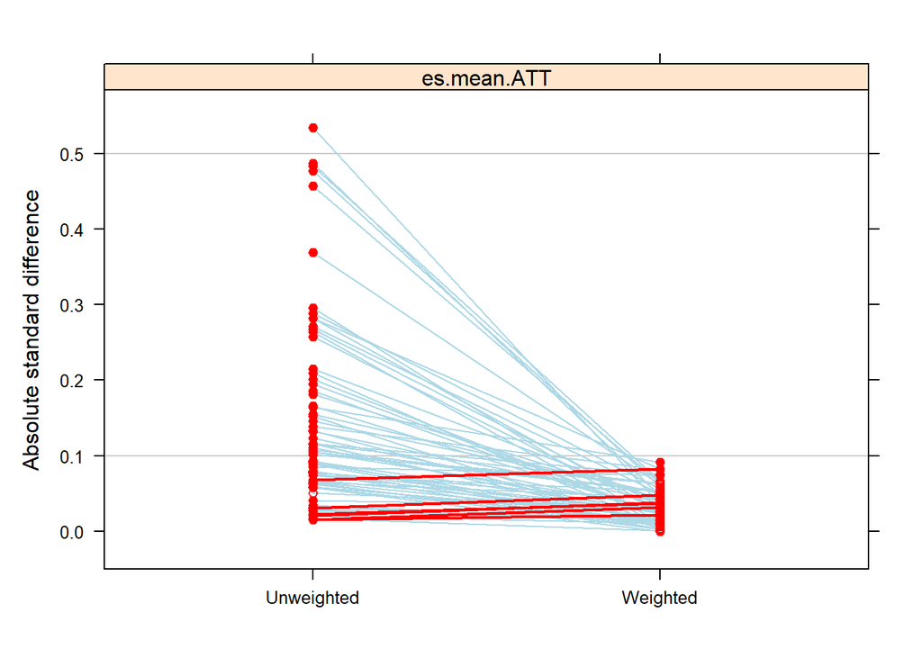

```r
plot(ps_rhc, plots = 3)
```

### 20.1.4 Assessing Balance with `cobalt`

```r
b2 <- bal.tab(ps_rhc, full.stop.method = "es.mean.att",
        stats = c("m", "v"), un = TRUE)

b2
```

```
Call
 ps.fast(formula = formula, data = data, params = params, n.trees = nrounds,
    interaction.depth = max_depth, shrinkage = eta, bag.fraction = subsample,
    n.minobsinnode = min_child_weight, perm.test.iters = perm.test.iters,
    print.level = print.level, verbose = verbose, estimand = estimand,
    stop.method = stop.method, sampw = sampw, multinom = multinom,
    ks.exact = ks.exact, version = version, tree_method = tree_method,
    n.keep = n.keep, n.grid = n.grid, keep.data = keep.data)

Balance Measures
                                 Type Diff.Un V.Ratio.Un Diff.Adj V.Ratio.Adj
prop.score                   Distance  1.5554     1.2083   0.5108      0.9058
age                           Contin. -0.0647     0.8175   0.0027      0.9662
sex_Female                     Binary -0.0462          .   0.0015           .
edu                           Contin.  0.0910     1.0147   0.0149      1.0020
income_Under $11k              Binary -0.0618          .  -0.0144           .
income_$11-$25k                Binary  0.0062          .  -0.0128           .
income_$25-$50k                Binary  0.0391          .   0.0245           .
income_> $50k                  Binary  0.0165          .   0.0027           .
ninsclas_Private               Binary  0.0624          .   0.0195           .
ninsclas_Private & Medicare    Binary  0.0143          .  -0.0057           .
ninsclas_Medicare              Binary -0.0327          .  -0.0011           .
ninsclas_Medicare & Medicaid   Binary -0.0144          .   0.0023           .
ninsclas_Medicaid              Binary -0.0395          .  -0.0231           .
ninsclas_No insurance          Binary  0.0099          .   0.0082           .
race_white                     Binary  0.0063          .  -0.0088           .
race_black                     Binary -0.0114          .   0.0062           .
race_other                     Binary  0.0050          .   0.0026           .
cat1_ARF                       Binary -0.0290          .  -0.0098           .
cat1_CHF                       Binary  0.0261          .  -0.0019           .
cat1_Cirrhosis                 Binary -0.0268          .  -0.0063           .
cat1_Colon Cancer              Binary -0.0012          .   0.0000           .
cat1_Coma                      Binary -0.0525          .  -0.0053           .
cat1_COPD                      Binary -0.0858          .  -0.0057           .
cat1_Lung Cancer               Binary -0.0073          .  -0.0002           .
cat1_MOSF w/Malignancy         Binary  0.0045          .   0.0002           .
cat1_MOSF w/Sepsis             Binary  0.1721          .   0.0289           .
dnr1_Yes                       Binary -0.0696          .  -0.0129           .
wtkilo1                       Contin.  0.2640     0.8835   0.0075      1.0408
hrt1                          Contin.  0.1460     1.0260   0.0506      0.9705
```

[output cut: 32 more lines]

```
alb1                          Contin. -0.2010     1.8947  -0.0217      1.6852
bili1                         Contin.  0.1329     1.4504  -0.0102      0.9447
crea1                         Contin.  0.2678     1.0276   0.0335      0.9294
hema1                         Contin. -0.2954     0.7109  -0.0098      0.9668
paco21                        Contin. -0.2880     0.5935  -0.0559      1.0124
pafi1                         Contin. -0.4566     0.8184  -0.0635      0.9492
ph1                           Contin. -0.1163     1.1322  -0.0754      1.1463
pot1                          Contin. -0.0274     0.9501  -0.0149      1.0131
sod1                          Contin. -0.0927     0.9799  -0.0272      1.0189
wblc1                         Contin.  0.0799     1.2088  -0.0110      1.0154

Effective sample sizes
           Control Treated
Unadjusted  3551.     2184
Adjusted    1250.5    2184
```

## 20.2 Rubin’s Rule 1 After Weighting

We could simply compare the propensity score balance as reported in the table above, looking at the standardized biases (the standardized difference on a proportion scale, rather than a percentage.) I’ll multiply each by 100 to place things on the usual scale.

```r
100*b2[1]$Balance$Diff.Un[1] # imbalance prior to weighting
```

```
[1] 155.5377
```

```r
100*b2[1]$Balance$Diff.Adj[1] # imbalance after weighting
```

```
[1] 51.07571
```

So this is still indicative of some difficulty reaching a completely reasonable level of balance. We’d like to see this much closer to 0.

## 20.3 Rubin’s Rule 2 After Weighting

```r
b2[1]$Balance$V.Ratio.Un[1] # imbalance prior to weighting
```

```
[1] 1.208331
```

```r
b2[1]$Balance$V.Ratio.Adj[1] # imbalance after weighting
```

```
[1] 0.9057622
```

So there’s no particular problem with Rule 2 here.

## 20.4 Semi-Automated Love plot of Standardized Differences

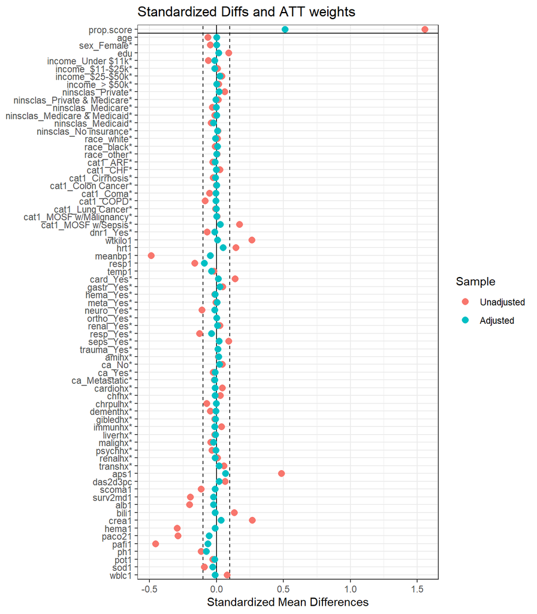

```r
p <- love.plot(b2,
               threshold = .1, size = 3, stars = "raw",
               title = "Standardized Diffs and ATT weights")
p + theme_bw()
```

## 20.5 Semi-Automated Love plot of Variance Ratios

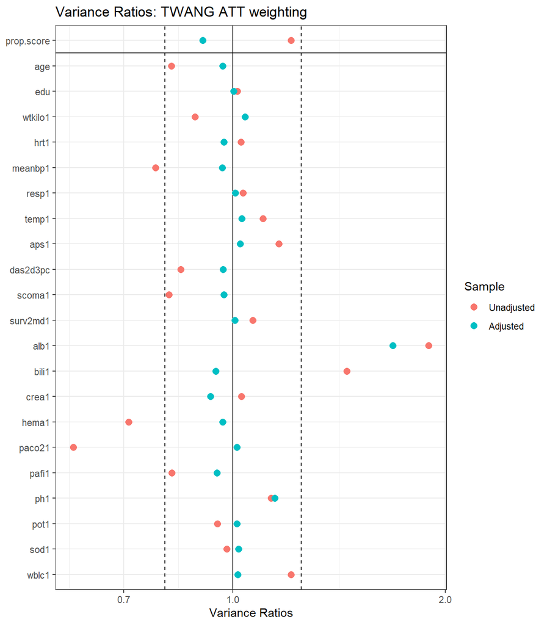

```r
p <- love.plot(b2, stat = "v",
               threshold = 1.25, size = 3,
               title = "Variance Ratios: TWANG ATT weighting")
p + theme_bw()
```

# 21 ATT Weighting Estimates

We’re not too excited about weighted estimates without (at least) an additional adjustment for differences in the propensity score in this case, but I’ll run them anyway just to show how that would be done.

## 21.1 Weighted ATT for Outcome A: Death

The relevant regression approach uses the `svydesign` and `svyglm` functions from the `survey` package. For a binary outcome, we build the outcome model using the quasibinomial, rather than the usual binomial family. Note the use of the 1/0 version of both the outcome and the treatment variables here.

```r
rhcwts_design <- svydesign(
    ids=~1, weights=~get.weights(ps_rhc,
                                 stop.method = "es.mean"),
    data=rhc_df) # using twang ATT weights


adj_death_wtd <- svyglm(died ~ treat_rhc,
                        design=rhcwts_design,
                      family=quasibinomial())

wt_twangatt_res_death <-
    tidy(adj_death_wtd, exponentiate = TRUE,
         conf.int = TRUE,
         conf.level = 0.95) %>%
    select(term, estimate, std.error,
           lo95 = conf.low, hi95 = conf.high)

wt_twangatt_res_death
```

```
# A tibble: 2 x 5
  term        estimate std.error  lo95  hi95
  <chr>          <dbl>     <dbl> <dbl> <dbl>
1 (Intercept)     1.73    0.0602  1.53  1.94
2 treat_rhc       1.23    0.0757  1.06  1.43
```

The estimates we want come from the `treat_rhc` row.

## 21.2 Double Robust Weighted Estimate for Death

Now let’s add in a regression adjustment for the linear propensity score, which should alleviate some of our concerns about residual imbalance after weighting.

```r
dr_adj_death <- svyglm(died ~ treat_rhc + linps,
                        design=rhcwts_design,
                      family=quasibinomial())

dr_death <-
    tidy(dr_adj_death, exponentiate = TRUE,
         conf.int = TRUE,
         conf.level = 0.95) %>%
    select(term, estimate, std.error,
           lo95 = conf.low, hi95 = conf.high)

dr_death
```

```
# A tibble: 3 x 5
  term        estimate std.error  lo95  hi95
  <chr>          <dbl>     <dbl> <dbl> <dbl>
1 (Intercept)    1.72     0.0612 1.52   1.94
2 treat_rhc      1.26     0.0812 1.07   1.47
3 linps          0.938    0.0415 0.864  1.02
```

Again, the estimates we want come from the `treat_rhc` row.

## 21.3 Graphing the Weighted and Matched Results for Outcome A

```r
temp7 <-
    tidy(adj_death_wtd, exponentiate = TRUE,
              conf.int = T, conf.level = 0.95) %>%
    filter(term == "treat_rhc")

temp8 <-
    tidy(dr_adj_death, exponentiate = TRUE,
              conf.int = T, conf.level = 0.95) %>%
    filter(term == "treat_rhc")

death_new_results <- rbind(temp7, temp8) %>%
    mutate(approach = c("ATT weighted", "DR")) %>%
    mutate(description = c("ATT weights", "DR: ATT wts + adj"))

death_results <- rbind(death_match_results,
                       death_new_results)

death_results
```

```
# A tibble: 9 x 9
  term      estimate std.error statistic  p.value conf.low conf.high approach
  <chr>        <dbl>     <dbl>     <dbl>    <dbl>    <dbl>     <dbl> <chr>
1 treat_rhc     1.25    0.0576      3.90 9.43e- 5     1.12      1.40 Unmatched
2 treat_rhc     1.26    0.0649      3.57 3.58e- 4     1.11      1.43 Match 1
3 treat_rhc     1.33    0.0548      5.27 1.37e- 7     1.20      1.49 Match 2
4 treat_rhc     1.32    0.0634      4.35 1.37e- 5     1.16      1.49 Match 3
5 treat_rhc     1.23    0.0636      3.22 1.27e- 3     1.08      1.39 Match 4
6 treat_rhc     1.33    0.0754      3.76 1.70e- 4     1.15      1.54 Match 5
7 treat_rhc     1.36    0.0491      6.25 4.18e-10     1.23      1.50 Match 6
8 treat_rhc     1.23    0.0757      2.78 5.50e- 3     1.06      1.43 ATT weight~
9 treat_rhc     1.26    0.0812      2.81 4.94e- 3     1.07      1.47 DR
# ... with 1 more variable: description <chr>
```

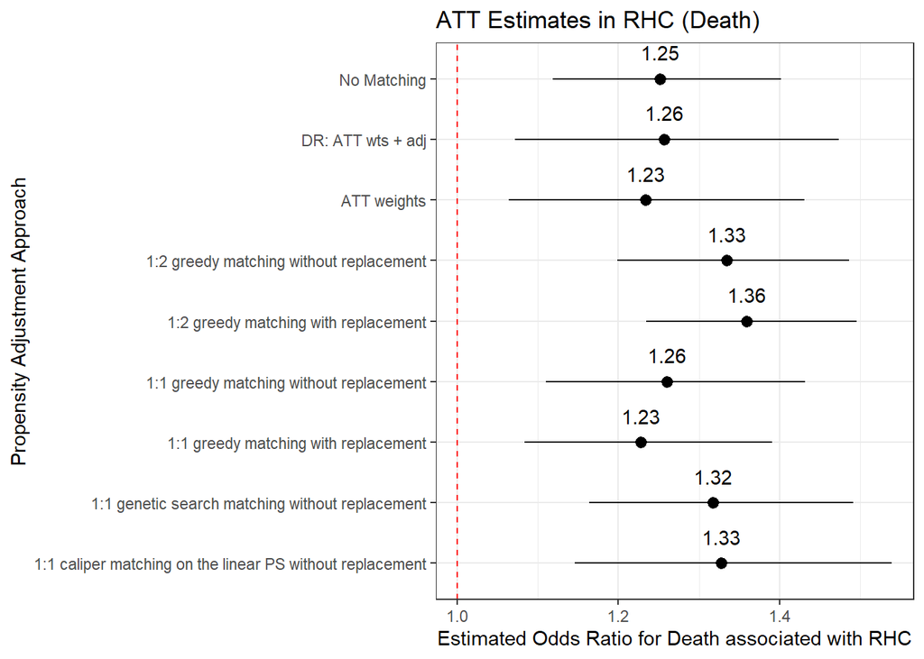

```r
death_results %>%
    ggplot(., aes(x = description, y = estimate,
                  ymin = conf.low, ymax = conf.high)) +
    geom_text(aes(label = round_half_up(estimate,2)), vjust = -1.25) +
    geom_pointrange() +
    geom_hline(yintercept = 1, col = "red", linetype = "dashed") +
    theme_bw() +
    coord_flip() +
    labs(title = "ATT Estimates in RHC (Death)",
         x = "Propensity Adjustment Approach",
         y = "Estimated Odds Ratio for Death associated with RHC")
```

And here are the results for only the five methods (adding our double robust approach to the analyses we liked in the matching) which showed reasonable balance after propensity score adjustment…

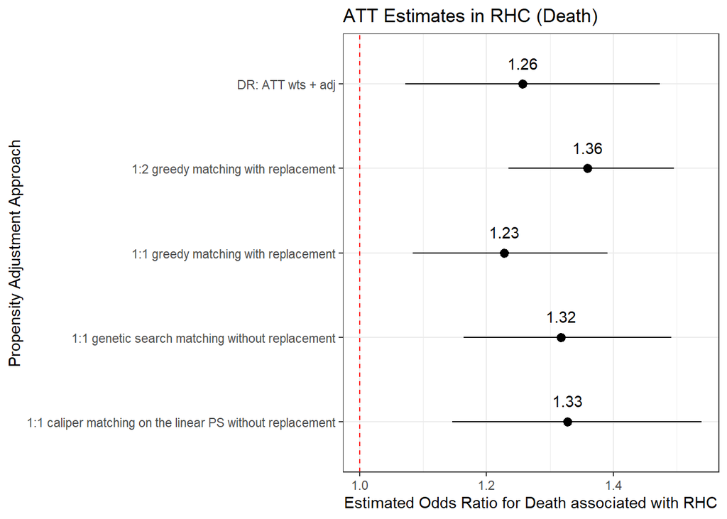

```r
death_results %>%
    filter(approach %in% c("Match 3", "Match 4", "Match 5",
                            "Match 6", "DR")) %>%
    ggplot(., aes(x = description, y = estimate,
                  ymin = conf.low, ymax = conf.high)) +
    geom_text(aes(label = round_half_up(estimate,2)), vjust = -1.25) +
    geom_pointrange() +
    geom_hline(yintercept = 1, col = "red", linetype = "dashed") +
    theme_bw() +
    coord_flip() +
    labs(title = "ATT Estimates in RHC (Death)",
         x = "Propensity Adjustment Approach",
         y = "Estimated Odds Ratio for Death associated with RHC")
```

## 21.4 Weighted ATT for Outcome B: Hospital Length of Stay

The relevant regression approach uses the `svydesign` and `svyglm` functions from the `survey` package.

```r
rhcwts_design <- svydesign(
    ids=~1, weights=~get.weights(ps_rhc,
                                 stop.method = "es.mean"),
    data=rhc_df) # using twang ATT weights

adj_hospdays_wtd <-
    svyglm(hospdays ~ treat_rhc,
           design= rhcwts_design)

wt_twangatt_res_hospdays <-
    tidy(adj_hospdays_wtd, conf.int = TRUE,
         conf.level = 0.95) %>%
    select(term, estimate, std.error,
           lo95 = conf.low, hi95 = conf.high)

wt_twangatt_res_hospdays
```

```
# A tibble: 2 x 5
  term        estimate std.error    lo95  hi95
  <chr>          <dbl>     <dbl>   <dbl> <dbl>
1 (Intercept)    22.6      0.844 20.9    24.2
2 treat_rhc       2.10     1.03   0.0750  4.12
```

The estimates we want come from the `treat_rhc` row.

## 21.5 Double Robust Weighted Estimate for LOS

Now let’s add in a regression adjustment for the linear propensity score. Again, we should have some additional faith in these results over those with just weighting alone, because of the failure of the weighting approach to pass Rubin’s Rule 1.

```r
dr_adj_days <- svyglm(hospdays ~ treat_rhc + linps,
                        design=rhcwts_design)

dr_los <-
    tidy(dr_adj_days, conf.int = TRUE,
         conf.level = 0.95) %>%
    select(term, estimate, std.error,
           lo95 = conf.low, hi95 = conf.high)

dr_los
```

```
# A tibble: 3 x 5
  term        estimate std.error   lo95  hi95
  <chr>          <dbl>     <dbl>  <dbl> <dbl>
1 (Intercept)    22.8      0.873 21.1   24.5
2 treat_rhc       1.56     1.10  -0.605  3.72
3 linps           1.93     0.507  0.934  2.92
```

Once again, the estimates we want come from the `treat_rhc` row.

## 21.6 Graphing the Weighted and Matched Results for Outcome B

```r
temp9 <-
    tidy(adj_hospdays_wtd, conf.int = T,
         conf.level = 0.95) %>%
    filter(term == "treat_rhc") %>%
    select(-statistic, -p.value)

temp10 <-
    tidy(dr_adj_days, conf.int = T,
         conf.level = 0.95) %>%
    filter(term == "treat_rhc") %>%
    select(-statistic, -p.value)

hospdays_new_results <- rbind(temp9, temp10) %>%
    mutate(approach = c("ATT weighted", "DR")) %>%
    mutate(description = c("ATT weights", "DR: ATT wts + adj"))

hospdays_results <- rbind(hospdays_match_results,
                       hospdays_new_results)

hospdays_results
```

```
# A tibble: 9 x 7
  term      estimate std.error conf.low conf.high approach     description
  <chr>        <dbl>     <dbl>    <dbl>     <dbl> <chr>        <chr>
1 treat_rhc     5.16     0.687   3.81        6.51 Unmatched    No Matching
2 treat_rhc     3.87     0.786   2.33        5.41 Match 1      1:1 greedy match~
3 treat_rhc     4.98     0.545   3.91        6.05 Match 2      1:2 greedy match~
4 treat_rhc     1.41     0.842  -0.240       3.06 Match 3      1:1 genetic sear~
5 treat_rhc     1.27     0.859  -0.411       2.96 Match 4      1:1 greedy match~
6 treat_rhc     2.30     0.919   0.496       4.10 Match 5      1:1 caliper matc~
7 treat_rhc     1.22     0.556   0.125       2.31 Match 6      1:2 greedy match~
8 treat_rhc     2.10     1.03    0.0750      4.12 ATT weighted ATT weights
9 treat_rhc     1.56     1.10   -0.605       3.72 DR           DR: ATT wts + adj
```

So there’s our table.

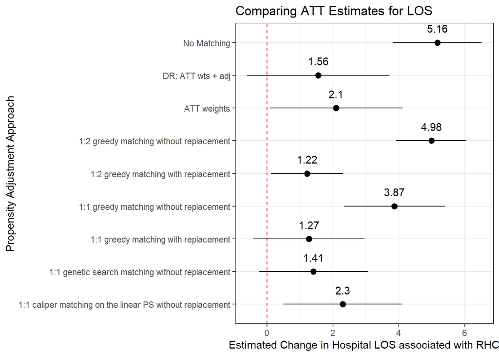

```r
hospdays_results %>%
    ggplot(., aes(x = description, y = estimate,
                  ymin = conf.low, ymax = conf.high)) +
    geom_text(aes(label = round_half_up(estimate,2)), vjust = -1.25) +
    geom_pointrange() +
    geom_hline(yintercept = 0, col = "red", linetype = "dashed") +
    theme_bw() +
    coord_flip() +
    labs(title = "Comparing ATT Estimates for LOS",
         x = "Propensity Adjustment Approach",
         y = "Estimated Change in Hospital LOS associated with RHC")
```

And here are the results for only the five methods (adding our double robust approach to the analyses we liked in the matching) which showed reasonable balance after propensity score adjustment…

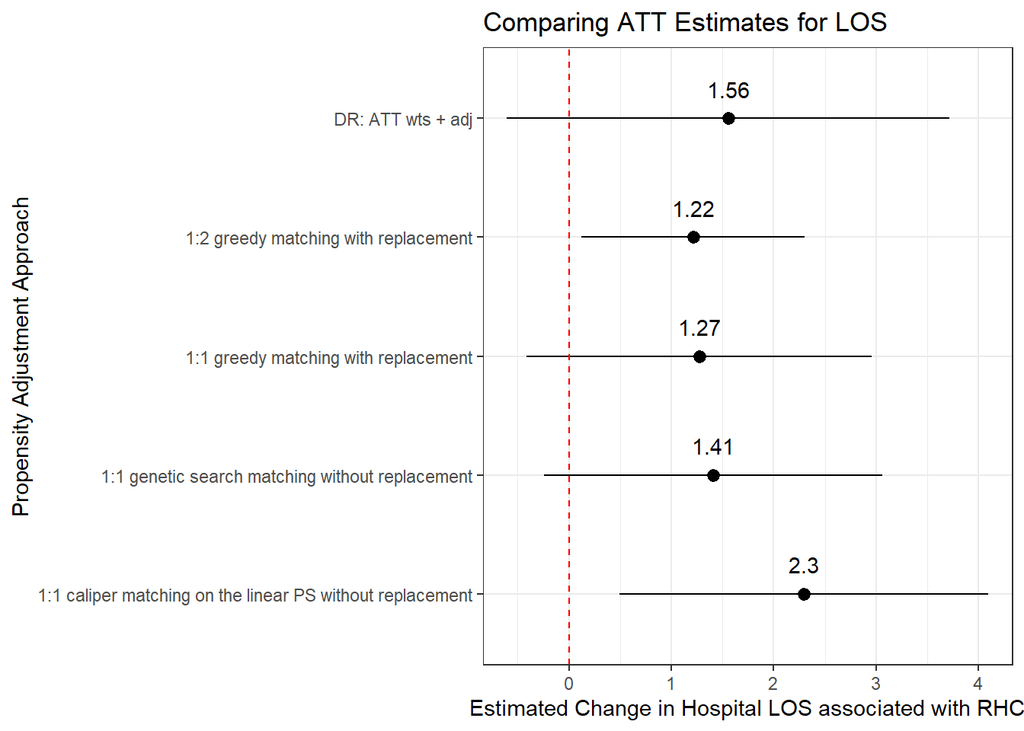

```r
hospdays_results %>%
    filter(approach %in% c("Match 3", "Match 4", "Match 5",
                            "Match 6", "DR")) %>%
    ggplot(., aes(x = description, y = estimate,
                  ymin = conf.low, ymax = conf.high)) +
    geom_text(aes(label = round_half_up(estimate,2)), vjust = -1.25) +
    geom_pointrange() +
    geom_hline(yintercept = 0, col = "red", linetype = "dashed") +
    theme_bw() +
    coord_flip() +
    labs(title = "Comparing ATT Estimates for LOS",
         x = "Propensity Adjustment Approach",
         y = "Estimated Change in Hospital LOS associated with RHC")
```

## 21.7 Weighted ATT for Outcome C: In-Study Time to Death

```r
rhc_wts <- get.weights(ps_rhc, stop.method = "es.mean")

adj_survdays_wtd <- coxph(Surv(survdays, died) ~ treat_rhc,
                          data = rhc_df, weights = rhc_wts)

wt_twangatt_res_surv <-
    tidy(adj_survdays_wtd, exponentiate = TRUE,
         conf.int = TRUE,
         conf.level = 0.95) %>%
    select(term, estimate, std.error,
           lo95 = conf.low, hi95 = conf.high)

wt_twangatt_res_surv
```

```
# A tibble: 1 x 5
  term      estimate std.error  lo95  hi95
  <chr>        <dbl>     <dbl> <dbl> <dbl>
1 treat_rhc     1.11    0.0396  1.02  1.22
```

Again, the estimates we want come from the `treat_rhc` row.

## 21.8 Double Robust Weighted Estimate for Days to Death

Now let’s add in a regression adjustment for the linear propensity score. Again, in this case, we prefer this double robust approach to weighting alone because of Rubin’s Rule 1 and the Love plot.

```r
dr_survdays <-
    coxph(Surv(survdays, died) ~ treat_rhc + linps,
          data = rhc_df, weights = rhc_wts)

dr_surv <-
    tidy(dr_survdays, exponentiate = TRUE,
         conf.int = TRUE,
         conf.level = 0.95) %>%
    select(term, estimate, std.error,
           lo95 = conf.low, hi95 = conf.high)

dr_surv
```

```
# A tibble: 2 x 5
  term      estimate std.error  lo95  hi95
  <chr>        <dbl>     <dbl> <dbl> <dbl>
1 treat_rhc    1.13     0.0399 1.03  1.23
2 linps        0.955    0.0173 0.913 0.999
```

Once again, the estimates we want come from the `treat_rhc` row.

## 21.9 Graphing the Weighted and Matched Results for Outcome C

```r
temp11 <-
    tidy(adj_survdays_wtd, exponentiate = T, conf.int = T,
         conf.level = 0.95) %>%
    filter(term == "treat_rhc") %>%
    select(-robust.se)

temp12 <-
    tidy(dr_survdays, exponentiate = T, conf.int = T,
         conf.level = 0.95) %>%
    filter(term == "treat_rhc") %>%
    select(-robust.se)

survdays_new_results <- rbind(temp11, temp12) %>%
    mutate(approach = c("ATT weighted", "DR")) %>%
    mutate(description = c("ATT weights", "DR: ATT wts + adj"))

survdays_results <- rbind(survdays_new_results,
                       survdays_match_results)

survdays_results
```

```
# A tibble: 9 x 9
  term      estimate std.error statistic  p.value conf.low conf.high approach
  <chr>        <dbl>     <dbl>     <dbl>    <dbl>    <dbl>     <dbl> <chr>
1 treat_rhc     1.11    0.0396      2.39 1.67e- 2    1.02       1.22 ATT weight~
2 treat_rhc     1.13    0.0399      2.55 1.09e- 2    1.03       1.23 DR
3 treat_rhc     1.08    0.0335      2.34 1.92e- 2    1.01       1.15 Unmatched
4 treat_rhc     1.05    0.0455      1.05 2.95e- 1    0.959      1.15 Match 1
5 treat_rhc     1.27    0.0343      7.02 2.17e-12    1.19       1.36 Match 2
6 treat_rhc     1.09    0.0445      2.03 4.26e- 2    1.00       1.19 Match 3
7 treat_rhc     1.06    0.0452      1.20 2.31e- 1    0.966      1.15 Match 4
8 treat_rhc     1.12    0.0535      2.05 3.99e- 2    1.01       1.24 Match 5
9 treat_rhc     1.36    0.0313      9.89 4.68e-23    1.28       1.45 Match 6
# ... with 1 more variable: description <chr>
```

So there’s our table.

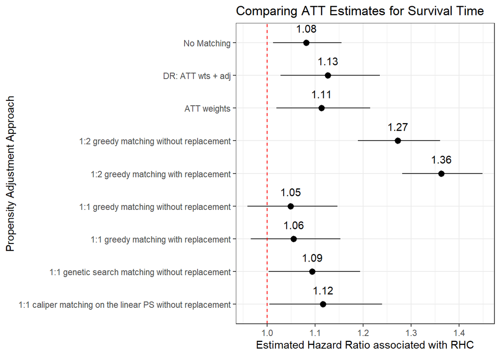

```r
survdays_results %>%
    ggplot(., aes(x = description, y = estimate,
                  ymin = conf.low, ymax = conf.high)) +
    geom_text(aes(label = round_half_up(estimate,2)), vjust = -1.25) +
    geom_pointrange() +
    geom_hline(yintercept = 1, col = "red", linetype = "dashed") +
    theme_bw() +
    coord_flip() +
    labs(title = "Comparing ATT Estimates for Survival Time",
         x = "Propensity Adjustment Approach",
         y = "Estimated Hazard Ratio associated with RHC")
```

And here are the results for only the five methods (adding our double robust approach to the analyses we liked in the matching) which showed reasonable balance after propensity score adjustment…

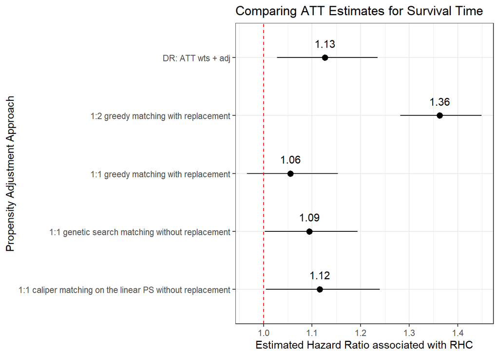

```r
survdays_results %>%
    filter(approach %in% c("Match 3", "Match 4", "Match 5",
                            "Match 6", "DR")) %>%
    ggplot(., aes(x = description, y = estimate,
                  ymin = conf.low, ymax = conf.high)) +
    geom_text(aes(label = round_half_up(estimate,2)), vjust = -1.25) +
    geom_pointrange() +
    geom_hline(yintercept = 1, col = "red", linetype = "dashed") +
    theme_bw() +
    coord_flip() +
    labs(title = "Comparing ATT Estimates for Survival Time",
         x = "Propensity Adjustment Approach",
         y = "Estimated Hazard Ratio associated with RHC")
```

# 22 Sensitivity Analyses After Matching

## 22.1 For the Binary Outcome, Death

The `rbounds` package can evaluate binary outcomes using the `binarysens` and `Fishersens` functions. The `binarysens` function works directly on a matched sample as developed using the Matching package. For example, in our third match, based on the genetic search algorithm with 1:1 matching without replacement, this is `match3`. Note that in order to do this, we needed to run `match3` including the appropriate (binary) outcome (Y).

```r
Y <- rhc$died
X <- cbind(rhc$linps, rhc$ps)
Tr <- as.logical(rhc$swang1 == "RHC")
match3 <- Match(Y = Y, Tr = Tr, X = X, estimand = "ATT",
                 Weight.matrix = genout3)
binarysens(match3, Gamma = 1.5, GammaInc = 0.05)
```

```
 Rosenbaum Sensitivity Test

Unconfounded estimate ....  0

 Gamma Lower bound Upper bound
  1.00       1e-05     0.00001
  1.05       0e+00     0.00020
  1.10       0e+00     0.00260
  1.15       0e+00     0.01854
  1.20       0e+00     0.07975
  1.25       0e+00     0.22444
  1.30       0e+00     0.44660
  1.35       0e+00     0.67877
  1.40       0e+00     0.85082
  1.45       0e+00     0.94458
  1.50       0e+00     0.98337

 Note: Gamma is Odds of Differential Assignment To
 Treatment Due to Unobserved Factors
```

At a 5% significance level, we retain significance up to a hidden bias of $\Gamma$ = 1.15, but not at $\Gamma$ = 1.2. See the `toy_2019` example discussed in Class 4, as well as Chapter 9 of Rosenbaum’s *Observation and Experiment* for more details on interpretation of this result.

We can also use this approach with other Matching results, including Match 6, which is a 1:2 match with replacement. Again, we have to run the match with the appropriate outcome included.

```r
Y <- rhc$died
X <- rhc$linps
Tr <- as.logical(rhc$swang1 == "RHC")
match6 <- Match(Y = Y, Tr = Tr, X = X, M = 2,
                estimand = "ATT", replace = TRUE,
                ties = FALSE)

binarysens(match6, Gamma = 1.5, GammaInc = 0.05)
```

```
 Rosenbaum Sensitivity Test

Unconfounded estimate ....  0

 Gamma Lower bound Upper bound
  1.00           0     0.00000
  1.05           0     0.00005
  1.10           0     0.00222
  1.15           0     0.03116
  1.20           0     0.17730
  1.25           0     0.48926
  1.30           0     0.79823
  1.35           0     0.95191
  1.40           0     0.99306
  1.45           0     0.99938
  1.50           0     0.99996

 Note: Gamma is Odds of Differential Assignment To
 Treatment Due to Unobserved Factors
```

Here, at a 5% significance level, we retain significance up to a hidden bias of $\Gamma$ = 1.15, but not at $\Gamma$ = 1.20.

## 22.2 For the Quantitative Outcome, In-Hospital Length of Stay

We have already used the `Match` function from the Matching package to develop our matched samples. For our 1:1 matches, we need only run the `psens` function from the `rbounds` package to obtain sensitivity results. For example, in Match 3,

```r
Y <- rhc$hospdays
X <- cbind(rhc$linps, rhc$ps)
Tr <- as.logical(rhc$swang1 == "RHC")
match3 <- Match(Y = Y, Tr = Tr, X = X, estimand = "ATT",
                 Weight.matrix = genout3)
psens(match3, Gamma = 1.5, GammaInc = 0.1)
```

```
 Rosenbaum Sensitivity Test for Wilcoxon Signed Rank P-Value

Unconfounded estimate ....  1e-04

 Gamma Lower bound Upper bound
   1.0       1e-04      0.0001
   1.1       0e+00      0.0410
   1.2       0e+00      0.5095
   1.3       0e+00      0.9501
   1.4       0e+00      0.9992
   1.5       0e+00      1.0000

 Note: Gamma is Odds of Differential Assignment To
 Treatment Due to Unobserved Factors
```

At a 5% significance level, we retain significance up to a hidden bias of $\Gamma$ = 1.1, but not at $\Gamma$ = 1.2. See the `toy_2019` example discussed in Class 4, as well as Chapter 9 of Rosenbaum’s *Observation and Experiment* for more details on interpretation of this result.

For a matching with more than 1 control, we need to apply the `mcontrol` function, which requires the use of the `data.prep` function from `rbounds`. So, for example, in Match 6, which is a 1:2 greedy match (so that each matched set has 3 patients in it, making the `group.size` = 3), we would have:

```r
Y <- rhc$hospdays
X <- rhc$linps
Tr <- as.logical(rhc$swang1 == "RHC")
match6 <- Match(Y = Y, Tr = Tr, X = X, M = 2,
                estimand = "ATT", replace = TRUE,
                ties = FALSE)

tmp <- data.prep(match6, group.size = 3)

mcontrol(tmp$Y, tmp$id, tmp$treat, group.size=3, Gamma = 1.5, GammaInc = 0.1)
```

```
 Rosenbaum Sensitivity Test for Wilcoxon Strat. Rank P-Value

Unconfounded estimate ....  0

 Gamma Lower bound Upper bound
   1.0           0      0.0000
   1.1           0      0.0177
   1.2           0      0.3501
   1.3           0      0.8834
   1.4           0      0.9960
   1.5           0      1.0000

 Note: Gamma is Odds of Differential Assignment To
 Treatment Due to Unobserved Factors
```

Again, at a 5% significance level, we retain significance up to a hidden bias of $\Gamma$ = 1.1, but not at $\Gamma$ = 1.2.

## 22.3 For the Survival Outcome, In-Study Time to Death

In this setting, we would need to use the spreadsheet software provided by Dr. Love. That software is designed only for 1:1 greedy matching without replacement or weighting, which is the approach we took in Match 1 (we could also have looked at matching using a caliper, but without replacement.) We need to identify, for each matched pair of subjects, whether that pair’s set of results was:

- that the RHC patient definitely survived longer than the non-RHC patient
- that the non-RHC patient definitely survived longer than the RHC patient
- that it is unclear which patient survived longer, due to censoring

Here is some very fussy code that accomplishes this counting. This could probably be accomplished just as well with some sort of `case_when` statement, but it’s a bit tricky.

```r
a1 <- rhc.matches_1 %>%
    select(matches_1, swang1, death, survdays) %>%
    arrange(matches_1)
```

```r
a2 <- unite(a1, situation, swang1, death, sep = "_", remove = TRUE)

a3 <- spread(a2, situation, survdays)

a4 <- a3 %>%
    filter(complete.cases(`No RHC_Yes`, `RHC_Yes`)) %>%
    mutate(result = ifelse(`RHC_Yes` > `No RHC_Yes`, "RHC lived longer", "No RHC lived longer"))

a5 <- a3 %>%
    filter(complete.cases(`No RHC_No`, `RHC_No`)) %>%
    mutate(result = "No clear winner")

a6 <- a3 %>%
    filter(complete.cases(`No RHC_No`, `RHC_Yes`)) %>%
    mutate(result = ifelse(`RHC_Yes` > `No RHC_No`, "No clear winner", "No RHC lived longer"))

a7 <- a3 %>%
    filter(complete.cases(`No RHC_Yes`, `RHC_No`)) %>%
    mutate(result = ifelse(`RHC_No` > `No RHC_Yes`, "RHC lived longer", "No clear winner"))

a8 <- bind_rows(a4, a5, a6, a7)

a8 %>% tabyl(result) %>% adorn_totals()
```

```
              result    n   percent
     No clear winner  278 0.1272894
 No RHC lived longer  988 0.4523810
    RHC lived longer  918 0.4203297
               Total 2184 1.0000000
```

So we have counts for the pairs where a clear winner is identified, and we can enter the spreadsheet. We need the number of pairs with a clear winner, and the number of pairs where the No RHC patient lived longer than the RHC patient.